# Analyses of GSE223295

## PCA

Before we move on, lets do a **Principal Component analysis**. It is a good exploratory tool to find out how our samples relate to each other and if there are any obvious outliers. We would expect our replicates to be nearer to one another than to other samples, and more different samples should be further away.

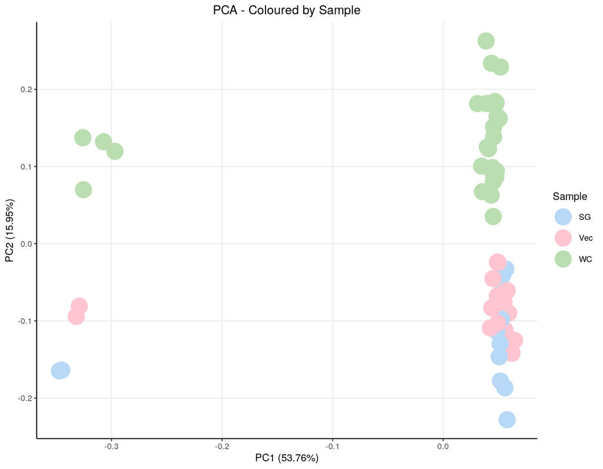

```r
# Define color palette
custom_palette <- qualitative_hcl(6, palette = "Pastel")
custom_palette <- sample(custom_palette, 6)


#This prepares my data for the PCA
dfforpca <- y$E
dfforpca <- t(dfforpca)
dfforpca <- as.data.frame(dfforpca) # needs to be a data.frame
dfforpca <- apply(dfforpca, 2, as.numeric) # Ensure numeric
dfforpca <- as.data.frame(dfforpca) # still needs to be a data.frame

# Add metadata, which we will then use to plot
dfforpca$Sample <- Biotype
dfforpca$Stress <- StressType
dfforpca$Cell <- CellType

# PCA computation itself. I do one PCA for each variable I want to see.
pca_res <- prcomp(dfforpca[, 1:(ncol(dfforpca)-3)], scale = FALSE)

p_Sample <- autoplot(pca_res, data = dfforpca, x = 1, y = 2, colour = "Sample", size = 8) +
  theme_bw() +
  scale_colour_manual(name = "Sample", values = custom_palette) +
  ggtitle("PCA - Coloured by Sample") +
  theme(plot.title = element_text(hjust = 0.5),
        axis.line = element_line(colour = "black"),
        panel.grid.minor = element_blank(),
        panel.border = element_blank(),
        panel.background = element_blank())

p_Stress <- autoplot(pca_res, data = dfforpca, x = 1, y = 2, colour = "Stress", size = 8) +
  theme_bw() +
  scale_colour_manual(name = "Stress", values = custom_palette) +
  ggtitle("PCA - Coloured by Stress") +
  theme(plot.title = element_text(hjust = 0.5),
        axis.line = element_line(colour = "black"),
        panel.grid.minor = element_blank(),
        panel.border = element_blank(),
        panel.background = element_blank())

p_Cell <- autoplot(pca_res, data = dfforpca, x = 1, y = 2, colour = "Cell", size = 8) +
  theme_bw() +
  scale_colour_manual(name = "Cell", values = custom_palette) +
  ggtitle("PCA - Coloured by Cell") +
  theme(plot.title = element_text(hjust = 0.5),
        axis.line = element_line(colour = "black"),
        panel.grid.minor = element_blank(),
        panel.border = element_blank(),
        panel.background = element_blank())

p_Sample
```

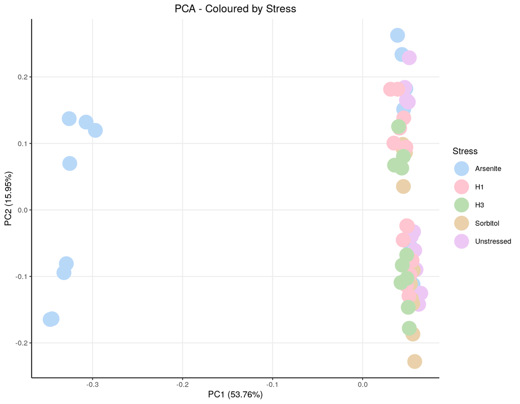

```r
p_Stress
```

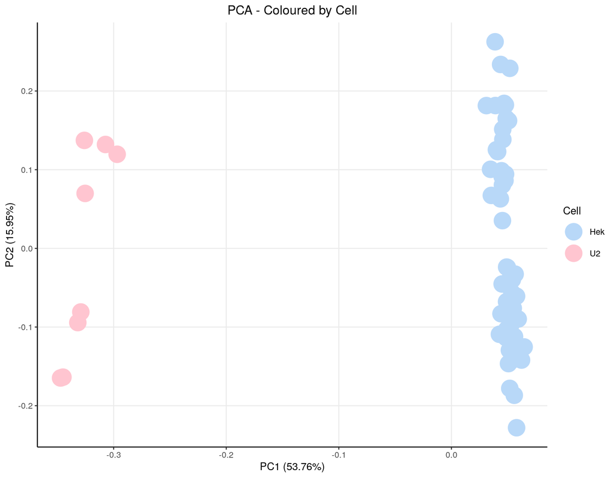

```r
p_Cell
```

```r
#in case you want to see most important genes for PCA yourself
contribs1 <- pca_res$rotation[,1]
contribs2 <- pca_res$rotation[,2]

#These are the biggest contributors to the PCA1 (right side)
(pos1genes <- sort(contribs1, decreasing=T)[1:10])
```

```
##       XIST       IRS4      UCHL1       H1-3     H2AC25     MARCKS        DSP
## 0.06675406 0.06371503 0.05659853 0.05626556 0.05536966 0.05516742 0.05452659
##     H2BC26     POU4F1     HSPA4L
## 0.05424669 0.05320850 0.05299861
```

```r
#These are the biggest contributors to the PCA1 (left side)
(neg1genes <- sort(contribs1, decreasing=F)[1:10])
```

```
##       KRT17       KRT81       KRT80      MAGEA4        H1-1      HAPLN1
## -0.07374066 -0.07220041 -0.07214685 -0.06926468 -0.06908965 -0.06691730
##        NNMT      TUBA3C       TENM2        CPA4
## -0.06676935 -0.06548096 -0.06518105 -0.06490230
```

```r
#These are the biggest contributors to the PCA2 (up side)
(pos2genes <- sort(contribs2, decreasing=T)[1:10])
```

```
##  RNA5SP202       RNY4      MT-TM      MT-TV     RNA5S9  RNA5SP149     RNU4-1
## 0.08772719 0.08202148 0.08141475 0.08062155 0.07388676 0.07329288 0.06908329
##  RNA5SP145    RNU5D-1     RNU4-2
## 0.06844449 0.06493697 0.06392503
```

```r
#These are the biggest contributors to the PCA2 (down side)
(neg2genes <- sort(contribs2, decreasing=F)[1:10])
```

```
##       NR1D2        NEK7       BNIP2       RRM2B      PPP4R2         TDG
## -0.02274538 -0.02255581 -0.02246833 -0.02239303 -0.02158960 -0.02080309
##       CEBPZ      PWWP3B      OSBPL8       ATAD2
## -0.02050750 -0.02040085 -0.02030554 -0.02023970
```

## Batch Effect Correction

Looking at the PCA I considered there was a clear batch effect owing to the cell type. I opted to remove this batch effect.

```r
batch_cols <- c("Cell")
metadata_cols <- c("Stress", "Bio")
mmbatch <- model.matrix(reformulate(paste0("~0 + ",paste0( batch_cols,collapse = " + "))), data=metadata)
mmkeep <- model.matrix(reformulate(paste0("~0 + ",paste0( metadata_cols,collapse =  "+" ))), data=metadata)
mm <- cbind(mmkeep,mmbatch)
D0 <- DGEList(2^y$E) #senescence_normcounts
D0 <- calcNormFactors(D0)
y <- voom(D0, mm, plot = F)
```

```
## Coefficients not estimable: CellU2
```

```r
fit <- lmFit(y, mm)
```

```
## Coefficients not estimable: CellU2
```

```r
beta <- fit$coefficients[,-(1:ncol(mmkeep)),drop=FALSE]
#beta <- fit$coefficients
beta[is.na(beta)] <- 0
corrcounts_v1 <- as.matrix(y$E) - beta %*% t(mmbatch)
offset <- apply(corrcounts_v1,1,min) - apply(y$E,1,min)
corrcounts_v1 <- as.data.frame(corrcounts_v1-offset)
corrcounts_v1 <- 2^corrcounts_v1
y <- voom(corrcounts_v1, mm)
```

```
## Coefficients not estimable: CellU2
```

## Batch Corrected PCA

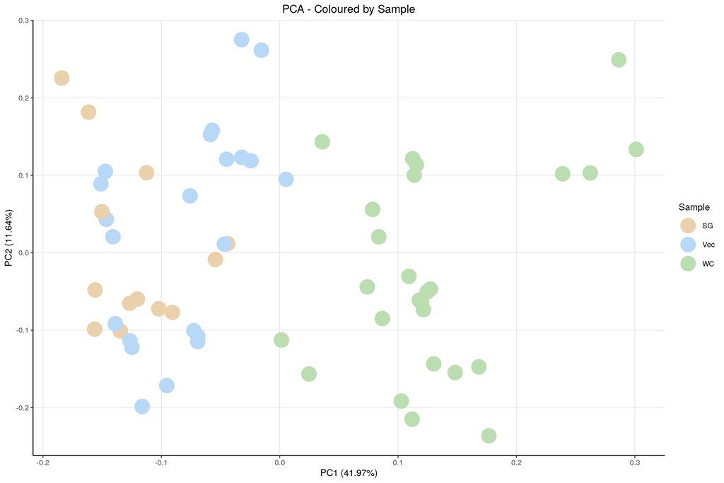

```r
# Define color palette
custom_palette <- qualitative_hcl(6, palette = "Pastel")
custom_palette <- sample(custom_palette, 6)


#This prepares my data for the PCA
dfforpca <- y$E
dfforpca <- t(dfforpca)
dfforpca <- as.data.frame(dfforpca) # needs to be a data.frame
dfforpca <- apply(dfforpca, 2, as.numeric) # Ensure numeric
dfforpca <- as.data.frame(dfforpca) # still needs to be a data.frame

# Add metadata, which we will then use to plot
dfforpca$Sample <- Biotype
dfforpca$Stress <- StressType
dfforpca$Cell <- CellType

# PCA computation itself. I do one PCA for each variable I want to see.
pca_res <- prcomp(dfforpca[, 1:(ncol(dfforpca)-3)], scale = FALSE)

p_Sample <- autoplot(pca_res, data = dfforpca, x = 1, y = 2, colour = "Sample", size = 8) +
  theme_bw() +
  scale_colour_manual(name = "Sample", values = custom_palette) +
  ggtitle("PCA - Coloured by Sample") +
  theme(plot.title = element_text(hjust = 0.5),
        axis.line = element_line(colour = "black"),
        panel.grid.minor = element_blank(),
        panel.border = element_blank(),
        panel.background = element_blank())

p_Stress <- autoplot(pca_res, data = dfforpca, x = 1, y = 2, colour = "Stress", size = 8) +
  theme_bw() +
  scale_colour_manual(name = "Stress", values = custom_palette) +
  ggtitle("PCA - Coloured by Stress") +
  theme(plot.title = element_text(hjust = 0.5),
        axis.line = element_line(colour = "black"),
        panel.grid.minor = element_blank(),
        panel.border = element_blank(),
        panel.background = element_blank())

p_Cell <- autoplot(pca_res, data = dfforpca, x = 1, y = 2, colour = "Cell", size = 8) +
  theme_bw() +
  scale_colour_manual(name = "Cell", values = custom_palette) +
  ggtitle("PCA - Coloured by Cell") +
  theme(plot.title = element_text(hjust = 0.5),
        axis.line = element_line(colour = "black"),
        panel.grid.minor = element_blank(),
        panel.border = element_blank(),
        panel.background = element_blank())

p_Sample
```

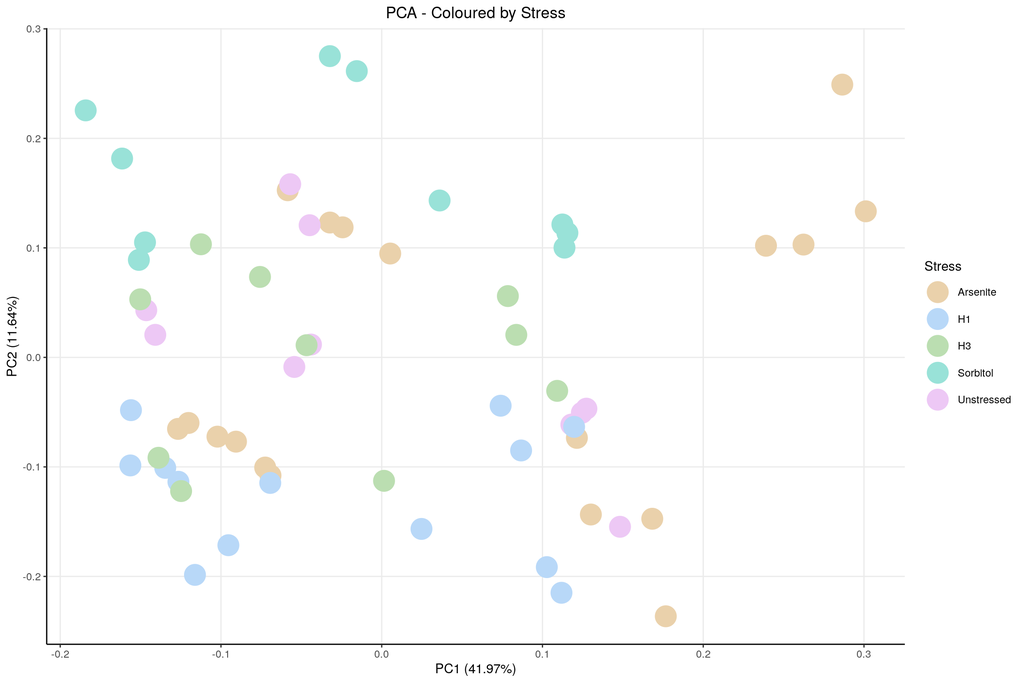

```r
p_Stress
```

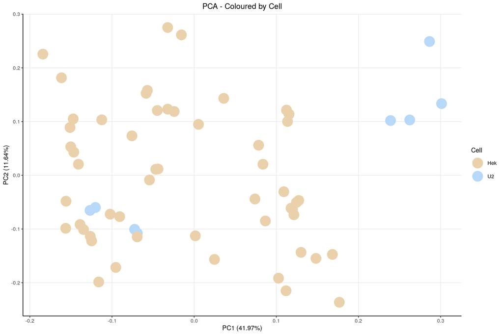

```r
p_Cell
```

```r
#in case you want to see most important genes for PCA yourself
contribs1 <- pca_res$rotation[,1]
contribs2 <- pca_res$rotation[,2]

#These are the biggest contributors to the PCA1 (right side)
(pos1genes <- sort(contribs1, decreasing=T)[1:10])
```

```
##  RNA5SP202     RNA5S9     RNU4-1      MT-TV       RNY4  RNA5SP149     RNU4-2
## 0.06234168 0.05451873 0.05038373 0.05015923 0.04815835 0.04805860 0.04645179
##      MT-TM    RNU5A-1    RNU5B-1
## 0.04636838 0.04380629 0.04297753
```

```r
#These are the biggest contributors to the PCA1 (left side)
(neg1genes <- sort(contribs1, decreasing=F)[1:10])
```

```
##        NEK7       NR1D2       RRM2B       EPRS1       BNIP2      PPP4R2
## -0.02508017 -0.02500938 -0.02461523 -0.02447791 -0.02441740 -0.02412562
##         TDG       CEBPZ       ATAD2       FEM1B
## -0.02375769 -0.02353356 -0.02347890 -0.02314662
```

```r
#These are the biggest contributors to the PCA2 (up side)
(pos2genes <- sort(contribs2, decreasing=T)[1:10])
```

```
##     MT-ND5     MT-ND2   MTATP6P1    MT-ATP8     MT-ND6       TSIX    MT-ATP6
## 0.03209688 0.03051691 0.03032352 0.02961384 0.02913151 0.02671535 0.02668204
##   MTND2P28     MT-CYB     MT-ND1
## 0.02632785 0.02623222 0.02506259
```

```r
#These are the biggest contributors to the PCA2 (down side)
(neg2genes <- sort(contribs2, decreasing=F)[1:10])
```

```
##         FOS        EGR1        FOSB        EGR3       HSPA6       CHAC1
## -0.09152325 -0.08351833 -0.06217517 -0.05725775 -0.05381946 -0.05275383
##       DDIT4         ARC     GADD45B        RNY4
## -0.04678514 -0.04670855 -0.04562849 -0.04449535
```

Now PC1 is driven by sample type instead.

# Simple Linear Models

Now we must perform linear model fitting.

```r
mm <- model.matrix(~0+SampleColouring)
y <- voom(corrcounts_v1, mm)
fitted <- lmFit(y$E, mm)

head(coef(fitted))
```

```
##           SampleColouringHekCtAsLabEn SampleColouringHekCtSoLabEn
## 5_8S_rRNA                    3.464522                    4.569168
## AAAS                         5.672195                    5.535870
## AACS                         4.995780                    4.823895
## AADAT                        4.404549                    3.822888
## AAGAB                        6.403583                    6.592384
## AAK1                         5.452768                    5.946963
##           SampleColouringHekCtT1LabEn SampleColouringHekCtT3LabEn
## 5_8S_rRNA                    5.161890                    6.060157
## AAAS                         5.612966                    5.515815
## AACS                         5.564001                    5.483353
## AADAT                        4.630559                    4.001223
## AAGAB                        6.944417                    6.677352
## AAK1                         5.513747                    5.462533
##           SampleColouringHekCtUnLabEn SampleColouringHekG3AsLabEn
## 5_8S_rRNA                    1.780444                    3.200417
## AAAS                         5.735472                    5.955171
## AACS                         5.188332                    5.396850
## AADAT                        4.171302                    4.568877
## AAGAB                        6.582578                    7.096370
## AAK1                         5.862059                    5.561041
##           SampleColouringHekG3AsLabIn SampleColouringHekG3AsNoLabEn
## 5_8S_rRNA                    5.257575                      4.078371
## AAAS                         6.357405                      7.146256
## AACS                         5.379029                      5.496330
## AADAT                        4.478005                      4.263852
## AAGAB                        6.134764                      5.775526
## AAK1                         5.264940                      5.293027
##           SampleColouringHekG3SoLabEn SampleColouringHekG3SoLabIn
## 5_8S_rRNA                    4.000077                    6.702031
## AAAS                         5.091789                    5.952525
## AACS                         4.861208                    5.141160
## AADAT                        4.179768                    3.111767
## AAGAB                        6.972578                    6.240745
## AAK1                         6.012086                    5.563590
##           SampleColouringHekG3SoNoLabEn SampleColouringHekG3T1LabEn
## 5_8S_rRNA                      4.957126                    3.190999
## AAAS                           6.322911                    5.429026
## AACS                           5.097635                    5.799752
## AADAT                          3.787247                    4.585326
```

[output cut: 29 more lines]

```
## AAK1                         6.082200                      6.131842
##           SampleColouringU2CtAsLabEn SampleColouringU2G3AsLabEn
## 5_8S_rRNA                   3.030324                   1.822690
## AAAS                        5.880916                   6.191288
## AACS                        5.423881                   5.319066
## AADAT                       4.403656                   4.897763
## AAGAB                       6.723526                   6.892810
## AAK1                        5.880189                   5.567179
##           SampleColouringU2G3AsLabIn SampleColouringU2G3AsNoLabEn
## 5_8S_rRNA                   3.760560                     5.416873
## AAAS                        5.688738                     6.476876
## AACS                        4.848247                     4.847266
## AADAT                       3.968310                     3.723850
## AAGAB                       5.471344                     5.509095
## AAK1                        4.595262                     4.913083
```

```r
#next we measure contrasts between groups (log-fold change is obtained from these fitted linear models)
U2.AS <- makeContrasts(SampleColouringU2G3AsLabEn  - SampleColouringU2G3AsLabIn, levels = (colnames(coef(fitted))))
HEK.AS<- makeContrasts(SampleColouringHekG3AsLabEn  - SampleColouringHekG3AsLabIn , levels = (colnames(coef(fitted))))
HEK.SO<- makeContrasts(SampleColouringHekG3SoLabEn  - SampleColouringHekG3SoLabIn , levels = (colnames(coef(fitted))))


#next we estimate the contrast for each gene
tmp.U2.AS  <- contrasts.fit(fitted, U2.AS )
tmp.HEK.AS <- contrasts.fit(fitted, HEK.AS)
tmp.HEK.SO <- contrasts.fit(fitted, HEK.SO)

#use empirical bayes smoothing of standard erros (shrinks extreme standard erros)
tmp.U2.AS <- eBayes(tmp.U2.AS)
tmp.HEK.AS <- eBayes(tmp.HEK.AS)
tmp.HEK.SO <- eBayes(tmp.HEK.SO)

top.table.U2.AS <- topTable(tmp.U2.AS, sort.by = "logFC", n=Inf)
top.table.HEK.AS <- topTable(tmp.HEK.AS, sort.by = "logFC", n=Inf)
top.table.HEK.SO<- topTable(tmp.HEK.SO, sort.by = "logFC", n=Inf)

DEGenes.U2.AS <- top.table.U2.AS
DEGenes.HEK.AS <- top.table.HEK.AS
DEGenes.HEK.SO <- top.table.HEK.SO





ndegs=20
```

# U2-OS Arsenite

## Volcano Plot

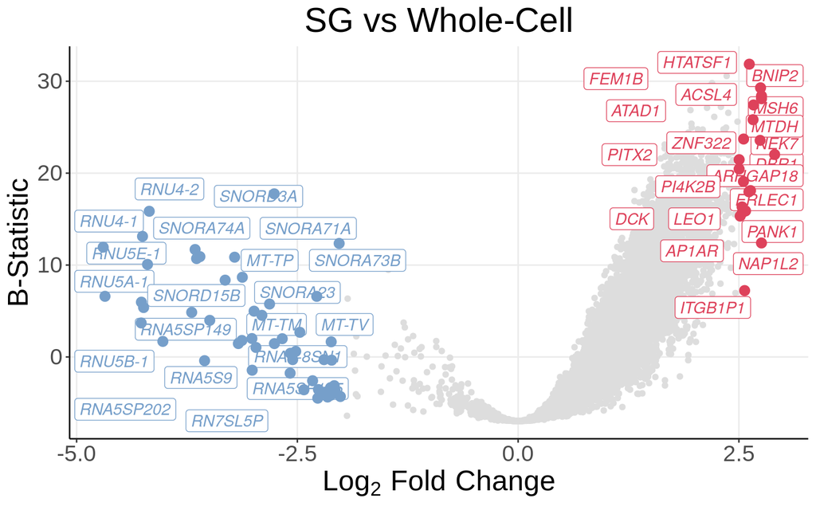

```r
write.table(x = DEGenes.U2.AS,
          file = "~/Projects/StressGranules/SGPAPER/SGvsWC/Ren_U2Ar.txt", sep="\t", col.names = TRUE, row.names = TRUE, quote=FALSE)

upmarkers <- as.data.frame(DEGenes.U2.AS[DEGenes.U2.AS$logFC>2.5 & DEGenes.U2.AS$adj.P.Val<0.05,] )
downmarkers <- as.data.frame(DEGenes.U2.AS[DEGenes.U2.AS$logFC< -2 & DEGenes.U2.AS$adj.P.Val<0.05,] )


ggplot(data=DEGenes.U2.AS,
                 aes(x=logFC,
                     y=  B)) +
  geom_point(color="#DDDDDD")+
  theme_bw() +
  theme(axis.line = element_line(colour = "black"),
        panel.grid.minor = element_blank(),
        panel.border = element_blank(),
        panel.background = element_blank()) +
  ggtitle("SG vs Whole-Cell")+
  theme(plot.title = element_text(hjust = 0.5)) +
  geom_label_repel(upmarkers[1:ndegs,] , mapping=aes(label=row.names(upmarkers)[1:ndegs]),size=4,point.padding=-0.5, color="#de425b",max.overlaps = 200, fontface="italic")+
  geom_label_repel(downmarkers[1:ndegs,] , mapping=aes(label=row.names(downmarkers)[1:ndegs]),size=4,point.padding=-0.5, color="#769fca",max.overlaps = 200, fontface="italic")+
  geom_point(data=upmarkers, aes(x=logFC, y=  B), color="#de425b", size=3)+
  geom_point(data=downmarkers, aes(x=logFC, y=  B), color="#769fca", size=3) + xlab(expression(Log[2] ~ Fold ~ Change)) + ylab("B-Statistic") + theme(text=element_text(family = "Arial", size = 20))
```

## Volcano Plot with Gene Lenght

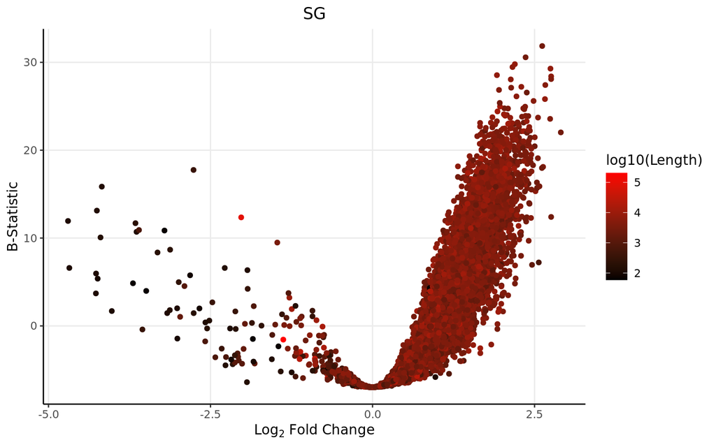

```r
DEGenes.U2.AS$Gene <- row.names(DEGenes.U2.AS)
colnames(genelength) <- c("Length","Gene")
DEGenes.U2.AS <- merge(DEGenes.U2.AS, genelength, by="Gene")

ggplot(data=DEGenes.U2.AS,
                 aes(x=logFC,
                     y=  B)) +
  geom_point(aes(color=log10(Length)))+
  theme_bw() +
  theme(axis.line = element_line(colour = "black"),
        panel.grid.minor = element_blank(),
        panel.border = element_blank(),
        panel.background = element_blank()) +
  ggtitle("SG")+ xlab(expression(Log[2] ~ Fold ~ Change)) + ylab("B-Statistic") +
  theme(plot.title = element_text(hjust = 0.5))  +
  scale_colour_gradient(low = "black", high = "red")+ theme(text=element_text(family = "Quicksand"))
```

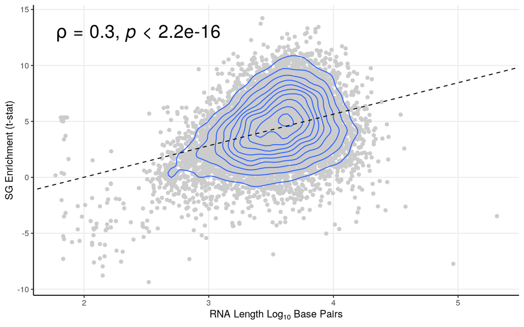

```r
smooth.SG <- lm(t~log10(Length), DEGenes.U2.AS)
liner.SG <- rstandard(smooth.SG)
DEGenes.U2.AS <-cbind(DEGenes.U2.AS, liner.SG)
colnames(DEGenes.U2.AS)[9] <- "Residuals"
row.names(DEGenes.U2.AS) <- DEGenes.U2.AS$Gene
linemarkers <- as.data.frame(DEGenes.U2.AS[abs(DEGenes.U2.AS$Residuals)>4,])

# Calculate the Spearman correlation coefficient
spearman_corr <- cor(DEGenes.U2.AS$t, log10(DEGenes.U2.AS$Length), method = "pearson")



ggplot(DEGenes.U2.AS, aes(y=t, x=log10(Length))) + geom_point(color="#CCCCCC", alpha=1) +   theme_bw()+ geom_density_2d()+
 ylab("SG Enrichment (t-stat)") + xlab(expression(RNA ~ Length ~ Log[10] ~ Base ~ Pairs)) +
  theme(axis.line = element_line(colour = "black"),
        panel.grid.minor = element_blank(),
        panel.border = element_blank(),
        panel.background = element_blank()) +
  theme(plot.title = element_text(hjust = 0.5))  +
  geom_abline(slope=smooth.SG$coefficients[2], intercept = smooth.SG$coefficients[1], linetype = "dashed")+ stat_cor(method = "spearman", cor.coef.name = "rho",size=7)
```

We see a positive lenght bias.

## Expression Graphs (Extra QC)

As an added control, lets plot these genes in regard to their expression. This helps to see if the expression differences are robust, and not just driven by one sample.

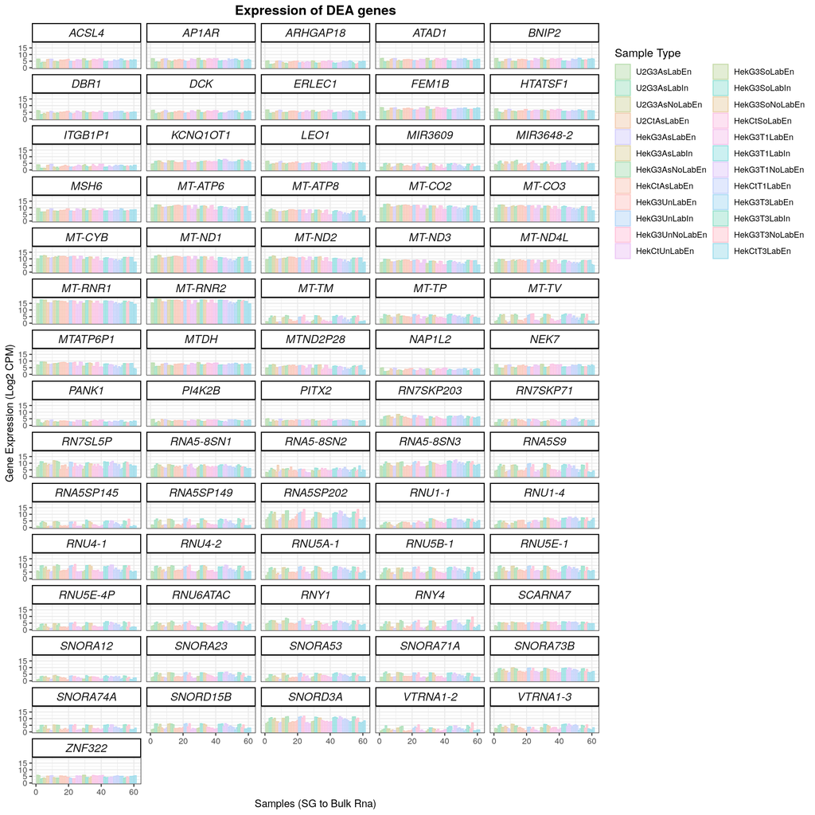

```r
# Define color palette
custom_palette <- qualitative_hcl(24, palette = "Pastel")
custom_palette <- sample(custom_palette, 24)

finagenes <- rbind(upmarkers, downmarkers)


dfforexpression <- dfforpca
samplecodes <- data.frame(samples=row.names(dfforexpression), purity=c(1:61))
sampletype <- data.frame(samples=row.names(dfforexpression), sampletype=SampleColouring)
dfforexpression <- t(dfforexpression)
genesforexp <- dfforexpression[row.names(dfforexpression)%in%row.names(finagenes),]
genesforexp <- reshape2::melt(genesforexp)
colnames(genesforexp) <- c("Gene", "samples", "expression")
genesforexp <- merge(genesforexp, samplecodes, by="samples")
genesforexp <- merge(genesforexp, sampletype, by="samples")
genesforexp <- genesforexp[,-1]
genesforexp[,2] <- as.numeric(genesforexp[,2])
genesforexp[,1] <- as.character(genesforexp[,1])
genesforexp <- genesforexp[order(genesforexp$Gene),]


winnyplot <- ggplot(genesforexp, aes(x=purity, y=expression, fill=sampletype, colour=sampletype)) + geom_bar(position="dodge", stat="identity", alpha=0.5) + facet_wrap(.~ Gene, ncol=5)
winnyplot <- winnyplot + scale_fill_manual(name = "Sample Type", values = custom_palette, breaks = unique(SampleColouring)) + scale_colour_manual(name = "Sample Type", values = custom_palette, breaks = unique(SampleColouring))
winnyplot <- winnyplot + theme_bw() + xlab("Samples (SG to Bulk Rna)") + ylab("Gene Expression (Log2 CPM)") + theme(
      strip.text.x = element_text(
        size = 12, face="italic"
        )) +
 theme(
   strip.background = element_rect(
     color="black", fill="#FFFFFF", size=1, linetype="solid"
     )
   ) + theme(
    #legend.position = c(.95, .40),
    legend.justification = c("right", "top"),
    legend.box.just = "right",
    ) + theme(legend.title = element_text(size = 12)) + ggtitle("Expression of DEA genes") + theme(plot.title = element_text(hjust = 0.5, size=14, face="bold"))
winnyplot
```

## GSEA Enrichment

Now that we have our genes of interest, it would also be interesting to see what are the **altered gene sets** between upregulated and downregulated transcripts from the above comparison. Therefore, lets perform a *Gene Set Enrichment Analysis*

```r
#for all genes
DEGenes.U2.AS <- DEGenes.U2.AS[order(DEGenes.U2.AS[,4]),]
gseatool <- DEGenes.U2.AS[,4]
gseatool <- as.data.frame(gseatool)
colnames(gseatool)[1] <- "t"
gseatool[,2] <- DEGenes.U2.AS$Gene
colnames(gseatool)[2] <- "Symbol"
gseatool <- gseatool[,c(2,1)]

vectorranks <- gseatool$t
names(vectorranks) <- gseatool$Symbol


#to load our pathways
hallmarks.gs <- msigdbr(species = "Homo sapiens", collection =  "H")

hallmarks.gsets <- hallmarks.gs %>% split(x = .$gene_symbol, f = .$gs_name)

for (set in names(hallmarks.gsets)){
  hallmarks.gsets[[set]] <- toupper(hallmarks.gsets[[set]])
}

hallmarks.res <- fgsea(pathways = hallmarks.gsets,
                       stats = vectorranks)
```

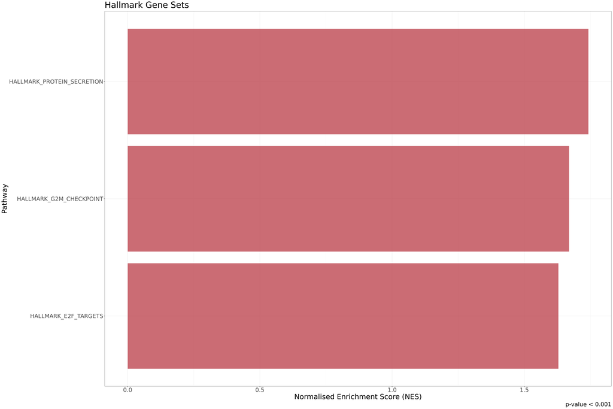

```r
hallmarks.res.tidy <- hallmarks.res %>%
  as_tibble() %>%
  arrange(desc(NES))

hallmarks.res.tidy %>%
  dplyr::select(-leadingEdge, -ES) %>%
  arrange(padj)

hallmark.sg.t <- hallmarks.res.tidy[,c(1,3,6)]
hallmark.sg.t <- as.data.frame(hallmark.sg.t)

#this small part is generic
thresh <- 0.001

#this one is no longer generic
data_to_plot <- hallmarks.res.tidy %>% filter(padj < thresh)

statvec <- c()
for (i in 1:nrow(data_to_plot)){
  if (data_to_plot[i,6] > 0){
    status <- "Upregulated"
  }
 else {
   status <- "Downregulated"
 }
statvec <- c(statvec, status)
}

data_to_plot$Status <- statvec

##-----HALMARK-----
gsea_plot_hall <- ggplot(data_to_plot, aes(reorder(pathway, NES), NES)) +
  geom_col(aes(fill= Status), alpha=0.75) + scale_fill_manual(values = c("#53A2BE","#BA3B46"), name = "Regulation Status", labels = c("Downregulated", "Upregulated"), breaks = c("Downregulated", "Upregulated")) +
  coord_flip() +
  labs(x="Pathway", y="Normalised Enrichment Score (NES)",
       title= "Hallmark Gene Sets",
       caption = paste0("p-value < ", thresh)) + theme(plot.title = element_text(hjust = 1)) +
  theme_bw() + theme(text=element_text(family = "Quicksand")) + theme(legend.position = "none")


gsea_plot_hall+
  theme(text=element_text(size=25,  family="Arial MS"))
```

## GSEA Length

Now, since SGs are enriched for longer transcripts, these pathways may simply be the ones which are tipically enriched in longer transcripts. Therefore, I will repeat the analysis, but using transcript lenght instead of t-statistic.

```r
#for all genes
DEGenes.U2.AS <- DEGenes.U2.AS[order(DEGenes.U2.AS[,8]),]
gseatool <- DEGenes.U2.AS[,8]
gseatool <- as.data.frame(gseatool)
colnames(gseatool)[1] <- "t"
gseatool[,2] <- DEGenes.U2.AS$Gene
colnames(gseatool)[2] <- "Symbol"
gseatool <- gseatool[,c(2,1)]

#for only the genes without the contamination


vectorranks <- log10(gseatool$t)
vectorranks <- scale(vectorranks)
names(vectorranks) <- gseatool$Symbol


#to load our pathways

##-----HALLMARK-----
hallmarks.gs <- msigdbr(species = "Homo sapiens", collection = "H")

hallmarks.gsets <- hallmarks.gs %>% split(x = .$gene_symbol, f = .$gs_name)

for (set in names(hallmarks.gsets)){
  hallmarks.gsets[[set]] <- toupper(hallmarks.gsets[[set]])
}

hallmarks.res <- fgsea(pathways = hallmarks.gsets,
                       stats = vectorranks)
```

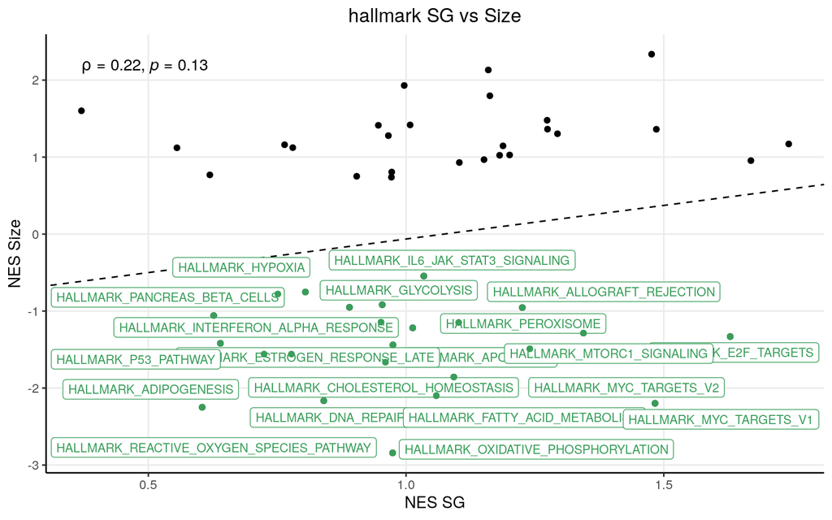

```r
hallmarks.res.tidy <- hallmarks.res %>%
  as_tibble() %>%
  arrange(desc(NES))

hallmarks.res.tidy %>%
  dplyr::select(-leadingEdge, -ES) %>%
  arrange(padj)

hallmark.size.t <- hallmarks.res.tidy[,c(1,3,6)]
hallmark.size.t <- as.data.frame(hallmark.size.t)


#HALLMARK
hallmark.scatter_ak <- merge(hallmark.sg.t, hallmark.size.t, by="pathway")
colnames(hallmark.scatter_ak) <- c("pathway", "sg_pval", "sg", "size_pval", "size")
hallmark.scatter_ak <- na.omit(hallmark.scatter_ak)
res_hallmark <- lm(size ~ sg, hallmark.scatter_ak)

vip.pathways_ak <- as.data.frame(hallmark.scatter_ak[(hallmark.scatter_ak$sg/hallmark.scatter_ak$size)<0,] )



ggplot(hallmark.scatter_ak, aes(x=sg, y=size)) + geom_point(color="black", alpha=01) +   theme_bw()+
 xlab("NES SG") + ylab("NES Size") +
  theme(axis.line = element_line(colour = "black"),
        panel.grid.minor = element_blank(),
        panel.border = element_blank(),
        panel.background = element_blank()) + ggtitle("hallmark SG vs Size")+
  theme(plot.title = element_text(hjust = 0.5)) +
  geom_abline(slope=res_hallmark$coefficients[2], intercept = res_hallmark$coefficients[1], linetype = "dashed") +
  geom_label_repel(vip.pathways_ak[1:ndegs,] , mapping=aes(label=vip.pathways_ak$pathway[1:ndegs]),size=3,point.padding=-0.5, color="#399e5a",max.overlaps = 200)+
  geom_point(data=vip.pathways_ak, aes(x=sg, y= size), color="#399e5a") + stat_cor(method = "spearman", cor.coef.name = "rho")
```

Even though there is some lenght bias in terms of enrichment, it does not seem to be linked in terms of gene set enrichment.

## Most altered pathways

I opted to see altered pathways as a whole. That is, ignoring bidirectionally and simply looking at what pathways are more altered as a whole (i.e, more expressed genes on either side).

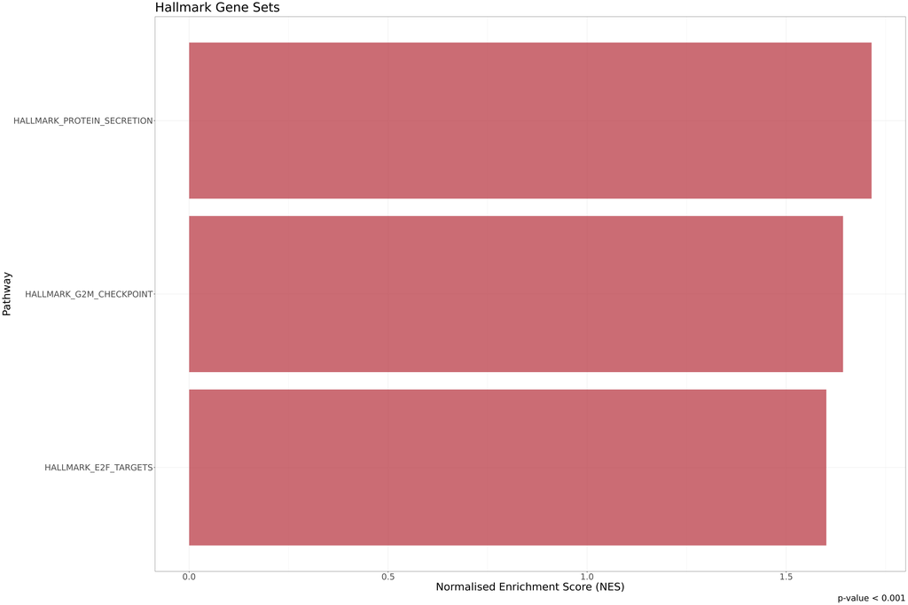

# HEK-293T Arsenite

## Volcano Plot

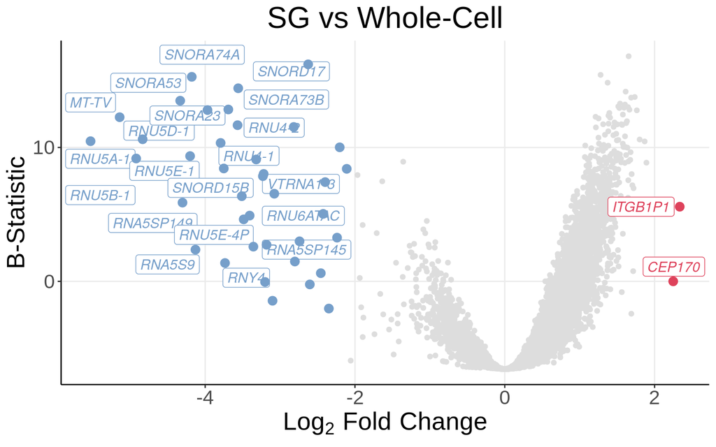

```r
write.table(x = DEGenes.HEK.AS,
          file = "~/Projects/StressGranules/SGPAPER/SGvsWC/Ren_HEKAr.txt", sep="\t", col.names = TRUE, row.names = TRUE, quote=FALSE)

upmarkers <- as.data.frame(DEGenes.HEK.AS[DEGenes.HEK.AS$logFC>2 & DEGenes.HEK.AS$adj.P.Val<0.05,] )
downmarkers <- as.data.frame(DEGenes.HEK.AS[DEGenes.HEK.AS$logFC< -2 & DEGenes.HEK.AS$adj.P.Val<0.05,] )


ggplot(data=DEGenes.HEK.AS,
                 aes(x=logFC,
                     y=  B)) +
  geom_point(color="#DDDDDD")+
  theme_bw() +
  theme(axis.line = element_line(colour = "black"),
        panel.grid.minor = element_blank(),
        panel.border = element_blank(),
        panel.background = element_blank()) +
  ggtitle("SG vs Whole-Cell")+
  theme(plot.title = element_text(hjust = 0.5)) +
  geom_label_repel(upmarkers[1:ndegs,] , mapping=aes(label=row.names(upmarkers)[1:ndegs]),size=4,point.padding=-0.5, color="#de425b",max.overlaps = 200, fontface="italic")+
  geom_label_repel(downmarkers[1:ndegs,] , mapping=aes(label=row.names(downmarkers)[1:ndegs]),size=4,point.padding=-0.5, color="#769fca",max.overlaps = 200, fontface="italic")+
  geom_point(data=upmarkers, aes(x=logFC, y=  B), color="#de425b", size=3)+
  geom_point(data=downmarkers, aes(x=logFC, y=  B), color="#769fca", size=3) + xlab(expression(Log[2] ~ Fold ~ Change)) + ylab("B-Statistic") + theme(text=element_text(family = "Arial", size = 20))
```

## Volcano Plot with Gene Lenght

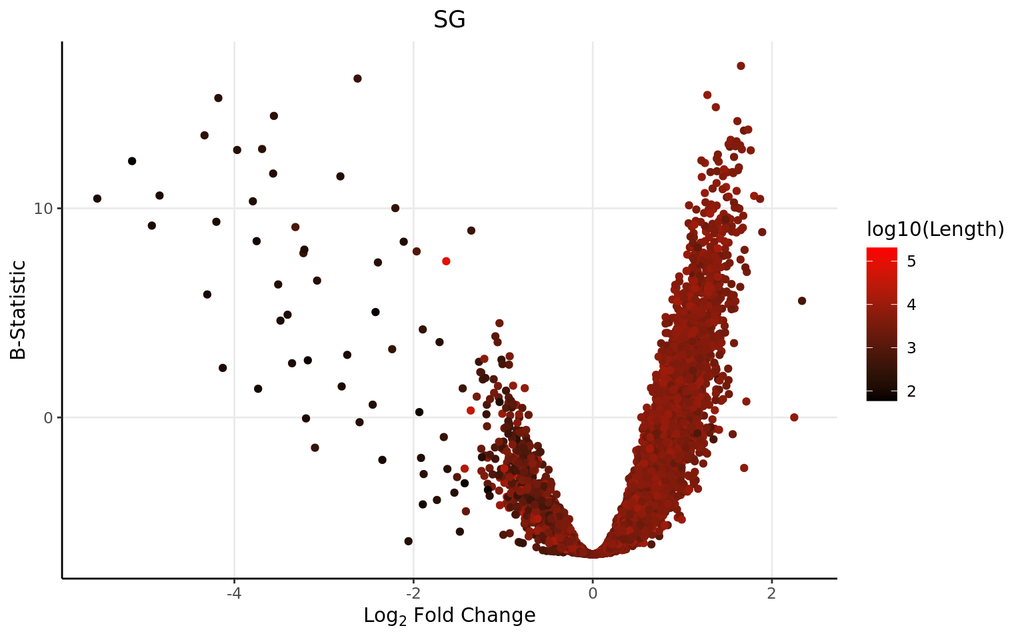

```r
DEGenes.HEK.AS$Gene <- row.names(DEGenes.HEK.AS)
colnames(genelength) <- c("Length","Gene")
DEGenes.HEK.AS <- merge(DEGenes.HEK.AS, genelength, by="Gene")

ggplot(data=DEGenes.HEK.AS,
                 aes(x=logFC,
                     y=  B)) +
  geom_point(aes(color=log10(Length)))+
  theme_bw() +
  theme(axis.line = element_line(colour = "black"),
        panel.grid.minor = element_blank(),
        panel.border = element_blank(),
        panel.background = element_blank()) +
  ggtitle("SG")+ xlab(expression(Log[2] ~ Fold ~ Change)) + ylab("B-Statistic") +
  theme(plot.title = element_text(hjust = 0.5))  +
  scale_colour_gradient(low = "black", high = "red")+ theme(text=element_text(family = "Quicksand"))
```

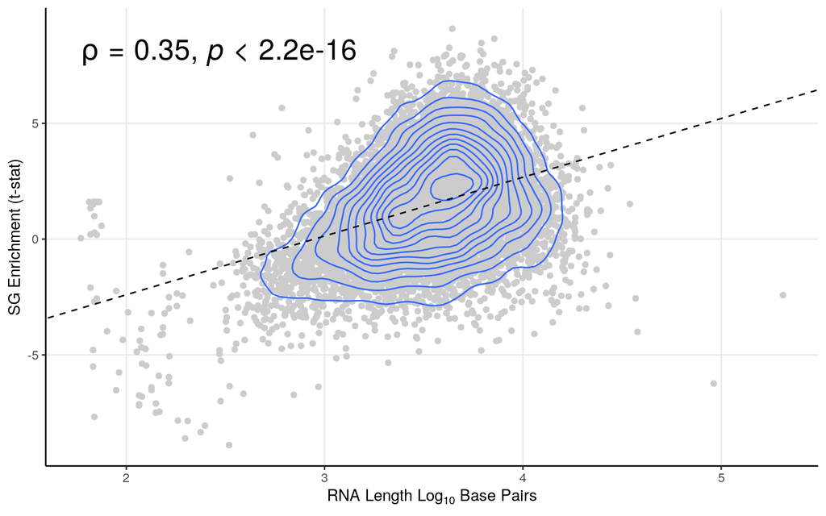

```r
smooth.SG <- lm(t~log10(Length), DEGenes.HEK.AS)
liner.SG <- rstandard(smooth.SG)
DEGenes.HEK.AS <-cbind(DEGenes.HEK.AS, liner.SG)
colnames(DEGenes.HEK.AS)[9] <- "Residuals"
row.names(DEGenes.HEK.AS) <- DEGenes.HEK.AS$Gene
linemarkers <- as.data.frame(DEGenes.HEK.AS[abs(DEGenes.HEK.AS$Residuals)>4,])

# Calculate the Spearman correlation coefficient
spearman_corr <- cor(DEGenes.HEK.AS$t, log10(DEGenes.HEK.AS$Length), method = "pearson")



ggplot(DEGenes.HEK.AS, aes(y=t, x=log10(Length))) + geom_point(color="#CCCCCC", alpha=1) +   theme_bw()+ geom_density_2d()+
 ylab("SG Enrichment (t-stat)") + xlab(expression(RNA ~ Length ~ Log[10] ~ Base ~ Pairs)) +
  theme(axis.line = element_line(colour = "black"),
        panel.grid.minor = element_blank(),
        panel.border = element_blank(),
        panel.background = element_blank()) +
  theme(plot.title = element_text(hjust = 0.5))  +
  geom_abline(slope=smooth.SG$coefficients[2], intercept = smooth.SG$coefficients[1], linetype = "dashed")+ stat_cor(method = "spearman", cor.coef.name = "rho",size=7)
```

We see a positive lenght bias.

## Expression Graphs (Extra QC)

As an added control, lets plot these genes in regard to their expression. This helps to see if the expression differences are robust, and not just driven by one sample.

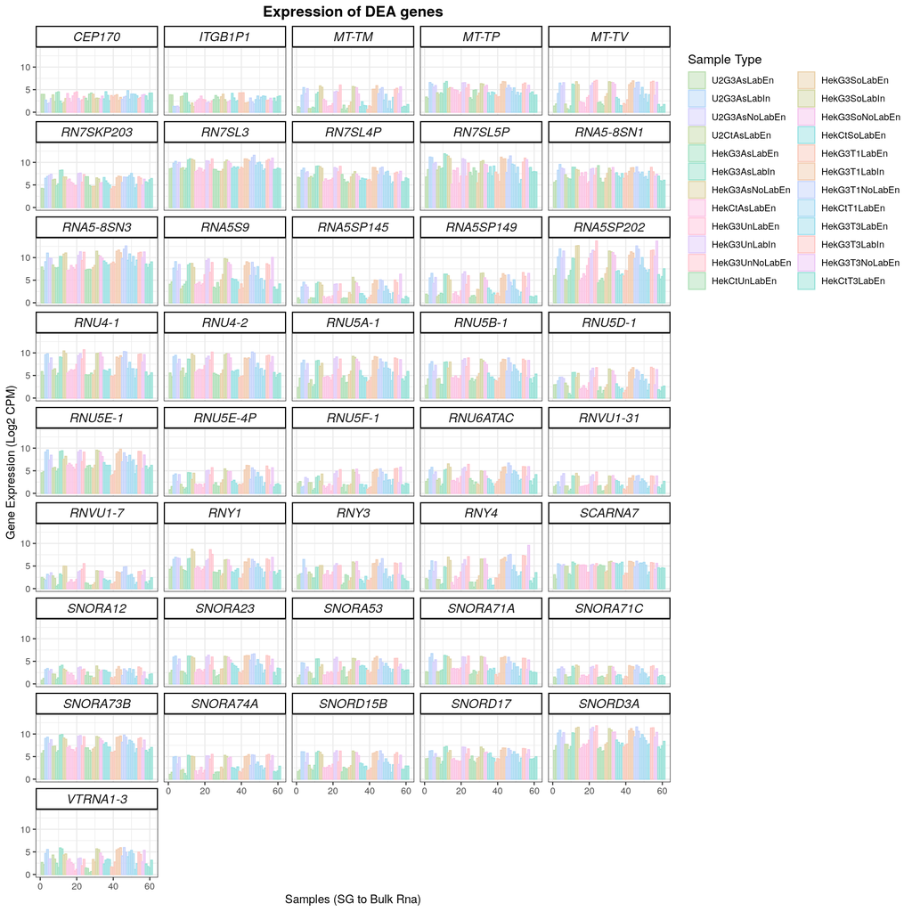

```r
# Define color palette
custom_palette <- qualitative_hcl(24, palette = "Pastel")
custom_palette <- sample(custom_palette, 24)

finagenes <- rbind(upmarkers, downmarkers)


dfforexpression <- dfforpca
samplecodes <- data.frame(samples=row.names(dfforexpression), purity=c(1:61))
sampletype <- data.frame(samples=row.names(dfforexpression), sampletype=SampleColouring)
dfforexpression <- t(dfforexpression)
genesforexp <- dfforexpression[row.names(dfforexpression)%in%row.names(finagenes),]
genesforexp <- reshape2::melt(genesforexp)
colnames(genesforexp) <- c("Gene", "samples", "expression")
genesforexp <- merge(genesforexp, samplecodes, by="samples")
genesforexp <- merge(genesforexp, sampletype, by="samples")
genesforexp <- genesforexp[,-1]
genesforexp[,2] <- as.numeric(genesforexp[,2])
genesforexp[,1] <- as.character(genesforexp[,1])
genesforexp <- genesforexp[order(genesforexp$Gene),]


winnyplot <- ggplot(genesforexp, aes(x=purity, y=expression, fill=sampletype, colour=sampletype)) + geom_bar(position="dodge", stat="identity", alpha=0.5) + facet_wrap(.~ Gene, ncol=5)
winnyplot <- winnyplot + scale_fill_manual(name = "Sample Type", values = custom_palette, breaks = unique(SampleColouring)) + scale_colour_manual(name = "Sample Type", values = custom_palette, breaks = unique(SampleColouring))
winnyplot <- winnyplot + theme_bw() + xlab("Samples (SG to Bulk Rna)") + ylab("Gene Expression (Log2 CPM)") + theme(
      strip.text.x = element_text(
        size = 12, face="italic"
        )) +
 theme(
   strip.background = element_rect(
     color="black", fill="#FFFFFF", size=1, linetype="solid"
     )
   ) + theme(
    #legend.position = c(.95, .40),
    legend.justification = c("right", "top"),
    legend.box.just = "right",
    ) + theme(legend.title = element_text(size = 12)) + ggtitle("Expression of DEA genes") + theme(plot.title = element_text(hjust = 0.5, size=14, face="bold"))
winnyplot
```

## GSEA Enrichment

Now that we have our genes of interest, it would also be interesting to see what are the **altered gene sets** between upregulated and downregulated transcripts from the above comparison. Therefore, lets perform a *Gene Set Enrichment Analysis*

```r
#for all genes
DEGenes.HEK.AS <- DEGenes.HEK.AS[order(DEGenes.HEK.AS[,4]),]
gseatool <- DEGenes.HEK.AS[,4]
gseatool <- as.data.frame(gseatool)
colnames(gseatool)[1] <- "t"
gseatool[,2] <- DEGenes.HEK.AS$Gene
colnames(gseatool)[2] <- "Symbol"
gseatool <- gseatool[,c(2,1)]

vectorranks <- gseatool$t
names(vectorranks) <- gseatool$Symbol


#to load our pathways
hallmarks.gs <- msigdbr(species = "Homo sapiens", collection =  "H")

hallmarks.gsets <- hallmarks.gs %>% split(x = .$gene_symbol, f = .$gs_name)

for (set in names(hallmarks.gsets)){
  hallmarks.gsets[[set]] <- toupper(hallmarks.gsets[[set]])
}

hallmarks.res <- fgsea(pathways = hallmarks.gsets,
                       stats = vectorranks)
```

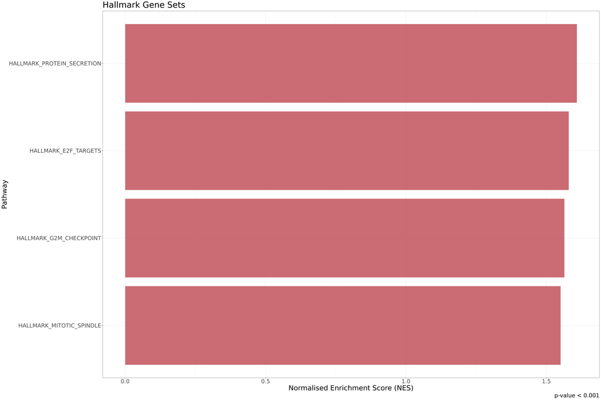

```r
hallmarks.res.tidy <- hallmarks.res %>%
  as_tibble() %>%
  arrange(desc(NES))

hallmarks.res.tidy %>%
  dplyr::select(-leadingEdge, -ES) %>%
  arrange(padj)

hallmark.sg.t <- hallmarks.res.tidy[,c(1,3,6)]
hallmark.sg.t <- as.data.frame(hallmark.sg.t)

#this small part is generic
thresh <- 0.001

#this one is no longer generic
data_to_plot <- hallmarks.res.tidy %>% filter(padj < thresh)

statvec <- c()
for (i in 1:nrow(data_to_plot)){
  if (data_to_plot[i,6] > 0){
    status <- "Upregulated"
  }
 else {
   status <- "Downregulated"
 }
statvec <- c(statvec, status)
}

data_to_plot$Status <- statvec

##-----HALMARK-----
gsea_plot_hall <- ggplot(data_to_plot, aes(reorder(pathway, NES), NES)) +
  geom_col(aes(fill= Status), alpha=0.75) + scale_fill_manual(values = c("#53A2BE","#BA3B46"), name = "Regulation Status", labels = c("Downregulated", "Upregulated"), breaks = c("Downregulated", "Upregulated")) +
  coord_flip() +
  labs(x="Pathway", y="Normalised Enrichment Score (NES)",
       title= "Hallmark Gene Sets",
       caption = paste0("p-value < ", thresh)) + theme(plot.title = element_text(hjust = 1)) +
  theme_bw() + theme(text=element_text(family = "Quicksand")) + theme(legend.position = "none")


gsea_plot_hall+
  theme(text=element_text(size=25,  family="Arial MS"))
```

## GSEA Length

Now, since SGs are enriched for longer transcripts, these pathways may simply be the ones which are tipically enriched in longer transcripts. Therefore, I will repeat the analysis, but using transcript lenght instead of t-statistic.

```r
#for all genes
DEGenes.HEK.AS <- DEGenes.HEK.AS[order(DEGenes.HEK.AS[,8]),]
gseatool <- DEGenes.HEK.AS[,8]
gseatool <- as.data.frame(gseatool)
colnames(gseatool)[1] <- "t"
gseatool[,2] <- DEGenes.HEK.AS$Gene
colnames(gseatool)[2] <- "Symbol"
gseatool <- gseatool[,c(2,1)]

#for only the genes without the contamination


vectorranks <- log10(gseatool$t)
vectorranks <- scale(vectorranks)
names(vectorranks) <- gseatool$Symbol


#to load our pathways

##-----HALLMARK-----
hallmarks.gs <- msigdbr(species = "Homo sapiens", collection = "H")

hallmarks.gsets <- hallmarks.gs %>% split(x = .$gene_symbol, f = .$gs_name)

for (set in names(hallmarks.gsets)){
  hallmarks.gsets[[set]] <- toupper(hallmarks.gsets[[set]])
}

hallmarks.res <- fgsea(pathways = hallmarks.gsets,
                       stats = vectorranks)
```

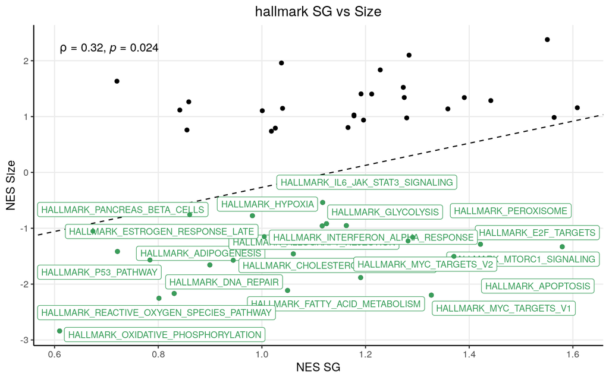

```r
hallmarks.res.tidy <- hallmarks.res %>%
  as_tibble() %>%
  arrange(desc(NES))

hallmarks.res.tidy %>%
  dplyr::select(-leadingEdge, -ES) %>%
  arrange(padj)

hallmark.size.t <- hallmarks.res.tidy[,c(1,3,6)]
hallmark.size.t <- as.data.frame(hallmark.size.t)


#HALLMARK
hallmark.scatter_ak <- merge(hallmark.sg.t, hallmark.size.t, by="pathway")
colnames(hallmark.scatter_ak) <- c("pathway", "sg_pval", "sg", "size_pval", "size")
hallmark.scatter_ak <- na.omit(hallmark.scatter_ak)
res_hallmark <- lm(size ~ sg, hallmark.scatter_ak)

vip.pathways_ak <- as.data.frame(hallmark.scatter_ak[(hallmark.scatter_ak$sg/hallmark.scatter_ak$size)<0,] )



ggplot(hallmark.scatter_ak, aes(x=sg, y=size)) + geom_point(color="black", alpha=01) +   theme_bw()+
 xlab("NES SG") + ylab("NES Size") +
  theme(axis.line = element_line(colour = "black"),
        panel.grid.minor = element_blank(),
        panel.border = element_blank(),
        panel.background = element_blank()) + ggtitle("hallmark SG vs Size")+
  theme(plot.title = element_text(hjust = 0.5)) +
  geom_abline(slope=res_hallmark$coefficients[2], intercept = res_hallmark$coefficients[1], linetype = "dashed") +
  geom_label_repel(vip.pathways_ak[1:ndegs,] , mapping=aes(label=vip.pathways_ak$pathway[1:ndegs]),size=3,point.padding=-0.5, color="#399e5a",max.overlaps = 200)+
  geom_point(data=vip.pathways_ak, aes(x=sg, y= size), color="#399e5a") + stat_cor(method = "spearman", cor.coef.name = "rho")
```

## Most altered pathways

I opted to see altered pathways as a whole. That is, ignoring bidirectionally and simply looking at what pathways are more altered as a whole (i.e, more expressed genes on either side).

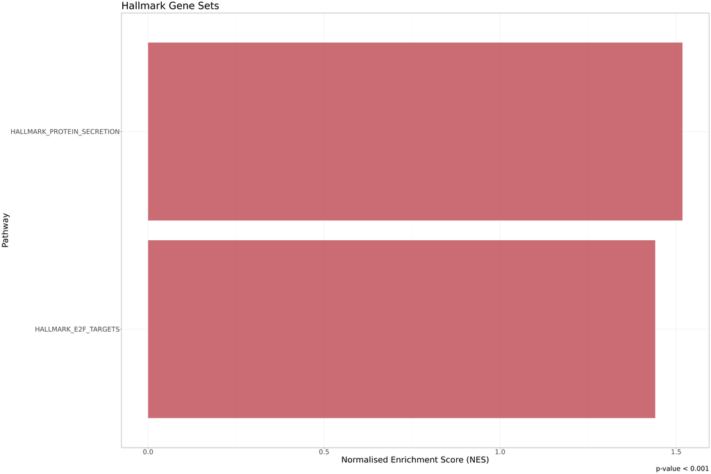

# HEK293T Sorbitol

## Volcano Plot

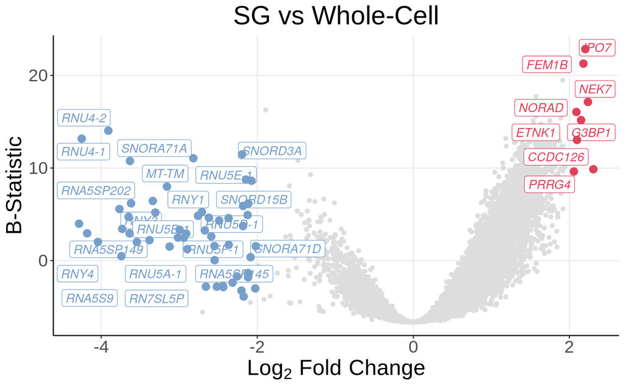

```r
write.table(x = DEGenes.HEK.SO,
          file = "~/Projects/StressGranules/SGPAPER/SGvsWC/Ren_HEKSo.txt", sep="\t", col.names = TRUE, row.names = TRUE, quote=FALSE)

upmarkers <- as.data.frame(DEGenes.HEK.SO[DEGenes.HEK.SO$logFC>2 & DEGenes.HEK.SO$adj.P.Val<0.05,] )
downmarkers <- as.data.frame(DEGenes.HEK.SO[DEGenes.HEK.SO$logFC< -2 & DEGenes.HEK.SO$adj.P.Val<0.05,] )


ggplot(data=DEGenes.HEK.SO,
                 aes(x=logFC,
                     y=  B)) +
  geom_point(color="#DDDDDD")+
  theme_bw() +
  theme(axis.line = element_line(colour = "black"),
        panel.grid.minor = element_blank(),
        panel.border = element_blank(),
        panel.background = element_blank()) +
  ggtitle("SG vs Whole-Cell")+
  theme(plot.title = element_text(hjust = 0.5)) +
  geom_label_repel(upmarkers[1:ndegs,] , mapping=aes(label=row.names(upmarkers)[1:ndegs]),size=4,point.padding=-0.5, color="#de425b",max.overlaps = 200, fontface="italic")+
  geom_label_repel(downmarkers[1:ndegs,] , mapping=aes(label=row.names(downmarkers)[1:ndegs]),size=4,point.padding=-0.5, color="#769fca",max.overlaps = 200, fontface="italic")+
  geom_point(data=upmarkers, aes(x=logFC, y=  B), color="#de425b", size=3)+
  geom_point(data=downmarkers, aes(x=logFC, y=  B), color="#769fca", size=3) + xlab(expression(Log[2] ~ Fold ~ Change)) + ylab("B-Statistic") + theme(text=element_text(family = "Arial", size = 20))
```

## Volcano Plot with Gene Lenght

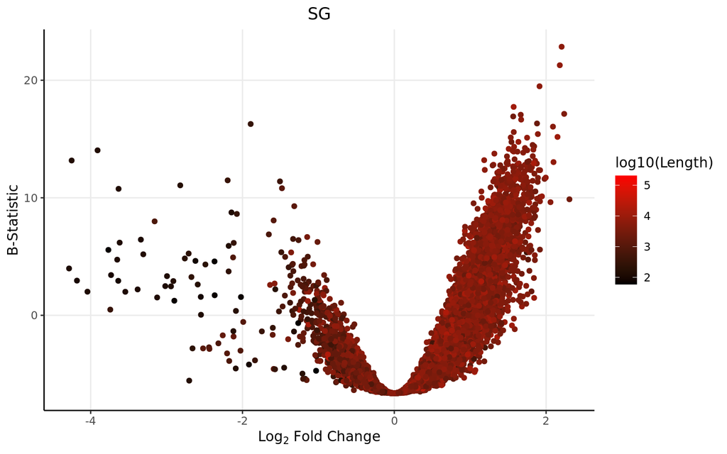

```r
DEGenes.HEK.SO$Gene <- row.names(DEGenes.HEK.SO)
colnames(genelength) <- c("Length","Gene")
DEGenes.HEK.SO <- merge(DEGenes.HEK.SO, genelength, by="Gene")

ggplot(data=DEGenes.HEK.SO,
                 aes(x=logFC,
                     y=  B)) +
  geom_point(aes(color=log10(Length)))+
  theme_bw() +
  theme(axis.line = element_line(colour = "black"),
        panel.grid.minor = element_blank(),
        panel.border = element_blank(),
        panel.background = element_blank()) +
  ggtitle("SG")+ xlab(expression(Log[2] ~ Fold ~ Change)) + ylab("B-Statistic") +
  theme(plot.title = element_text(hjust = 0.5))  +
  scale_colour_gradient(low = "black", high = "red")+ theme(text=element_text(family = "Quicksand"))
```

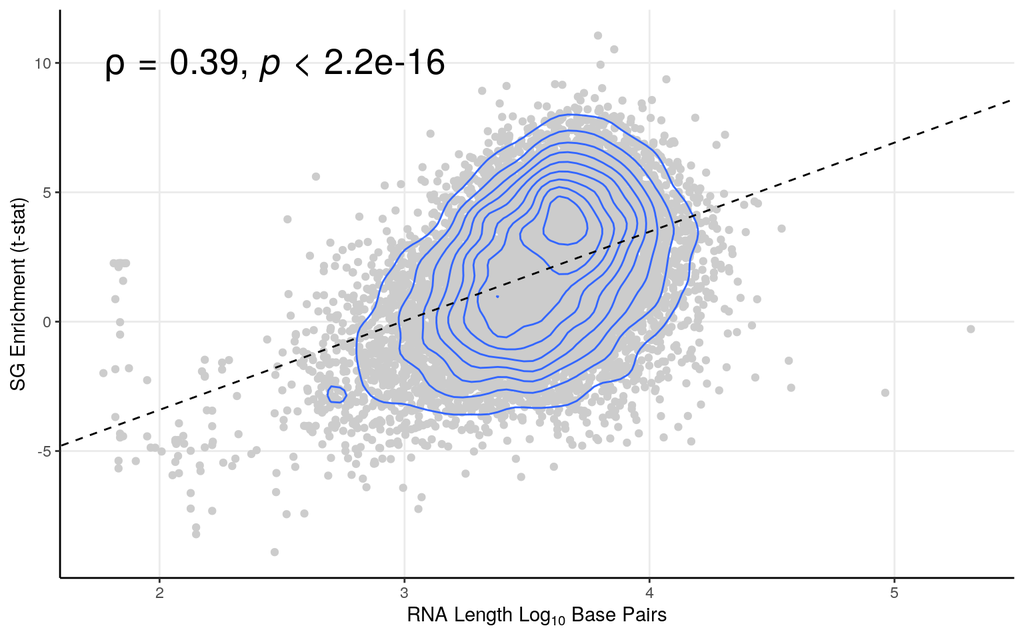

```r
smooth.SG <- lm(t~log10(Length), DEGenes.HEK.SO)
liner.SG <- rstandard(smooth.SG)
DEGenes.HEK.SO <-cbind(DEGenes.HEK.SO, liner.SG)
colnames(DEGenes.HEK.SO)[9] <- "Residuals"
row.names(DEGenes.HEK.SO) <- DEGenes.HEK.SO$Gene
linemarkers <- as.data.frame(DEGenes.HEK.SO[abs(DEGenes.HEK.SO$Residuals)>4,])

# Calculate the Spearman correlation coefficient
spearman_corr <- cor(DEGenes.HEK.SO$t, log10(DEGenes.HEK.SO$Length), method = "pearson")



ggplot(DEGenes.HEK.SO, aes(y=t, x=log10(Length))) + geom_point(color="#CCCCCC", alpha=1) +   theme_bw()+ geom_density_2d()+
 ylab("SG Enrichment (t-stat)") + xlab(expression(RNA ~ Length ~ Log[10] ~ Base ~ Pairs)) +
  theme(axis.line = element_line(colour = "black"),
        panel.grid.minor = element_blank(),
        panel.border = element_blank(),
        panel.background = element_blank()) +
  theme(plot.title = element_text(hjust = 0.5))  +
  geom_abline(slope=smooth.SG$coefficients[2], intercept = smooth.SG$coefficients[1], linetype = "dashed")+ stat_cor(method = "spearman", cor.coef.name = "rho",size=7)
```

We see a positive lenght bias.

## Expression Graphs (Extra QC)

As an added control, lets plot these genes in regard to their expression. This helps to see if the expression differences are robust, and not just driven by one sample.

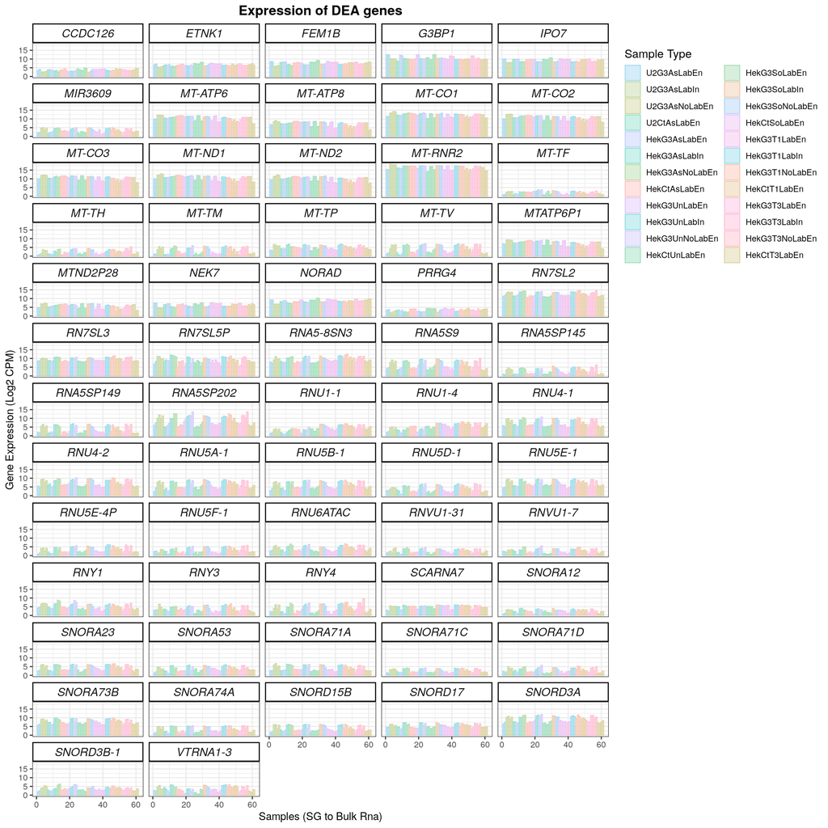

```r
# Define color palette
custom_palette <- qualitative_hcl(24, palette = "Pastel")
custom_palette <- sample(custom_palette, 24)

finagenes <- rbind(upmarkers, downmarkers)


dfforexpression <- dfforpca
samplecodes <- data.frame(samples=row.names(dfforexpression), purity=c(1:61))
sampletype <- data.frame(samples=row.names(dfforexpression), sampletype=SampleColouring)
dfforexpression <- t(dfforexpression)
genesforexp <- dfforexpression[row.names(dfforexpression)%in%row.names(finagenes),]
genesforexp <- reshape2::melt(genesforexp)
colnames(genesforexp) <- c("Gene", "samples", "expression")
genesforexp <- merge(genesforexp, samplecodes, by="samples")
genesforexp <- merge(genesforexp, sampletype, by="samples")
genesforexp <- genesforexp[,-1]
genesforexp[,2] <- as.numeric(genesforexp[,2])
genesforexp[,1] <- as.character(genesforexp[,1])
genesforexp <- genesforexp[order(genesforexp$Gene),]


winnyplot <- ggplot(genesforexp, aes(x=purity, y=expression, fill=sampletype, colour=sampletype)) + geom_bar(position="dodge", stat="identity", alpha=0.5) + facet_wrap(.~ Gene, ncol=5)
winnyplot <- winnyplot + scale_fill_manual(name = "Sample Type", values = custom_palette, breaks = unique(SampleColouring)) + scale_colour_manual(name = "Sample Type", values = custom_palette, breaks = unique(SampleColouring))
winnyplot <- winnyplot + theme_bw() + xlab("Samples (SG to Bulk Rna)") + ylab("Gene Expression (Log2 CPM)") + theme(
      strip.text.x = element_text(
        size = 12, face="italic"
        )) +
 theme(
   strip.background = element_rect(
     color="black", fill="#FFFFFF", size=1, linetype="solid"
     )
   ) + theme(
    #legend.position = c(.95, .40),
    legend.justification = c("right", "top"),
    legend.box.just = "right",
    ) + theme(legend.title = element_text(size = 12)) + ggtitle("Expression of DEA genes") + theme(plot.title = element_text(hjust = 0.5, size=14, face="bold"))
winnyplot
```

## GSEA Enrichment

Now that we have our genes of interest, it would also be interesting to see what are the **altered gene sets** between upregulated and downregulated transcripts from the above comparison. Therefore, lets perform a *Gene Set Enrichment Analysis*

```r
#for all genes
DEGenes.HEK.SO <- DEGenes.HEK.SO[order(DEGenes.HEK.SO[,4]),]
gseatool <- DEGenes.HEK.SO[,4]
gseatool <- as.data.frame(gseatool)
colnames(gseatool)[1] <- "t"
gseatool[,2] <- DEGenes.HEK.SO$Gene
colnames(gseatool)[2] <- "Symbol"
gseatool <- gseatool[,c(2,1)]

vectorranks <- gseatool$t
names(vectorranks) <- gseatool$Symbol


#to load our pathways
hallmarks.gs <- msigdbr(species = "Homo sapiens", collection =  "H")

hallmarks.gsets <- hallmarks.gs %>% split(x = .$gene_symbol, f = .$gs_name)

for (set in names(hallmarks.gsets)){
  hallmarks.gsets[[set]] <- toupper(hallmarks.gsets[[set]])
}

hallmarks.res <- fgsea(pathways = hallmarks.gsets,
                       stats = vectorranks)
```

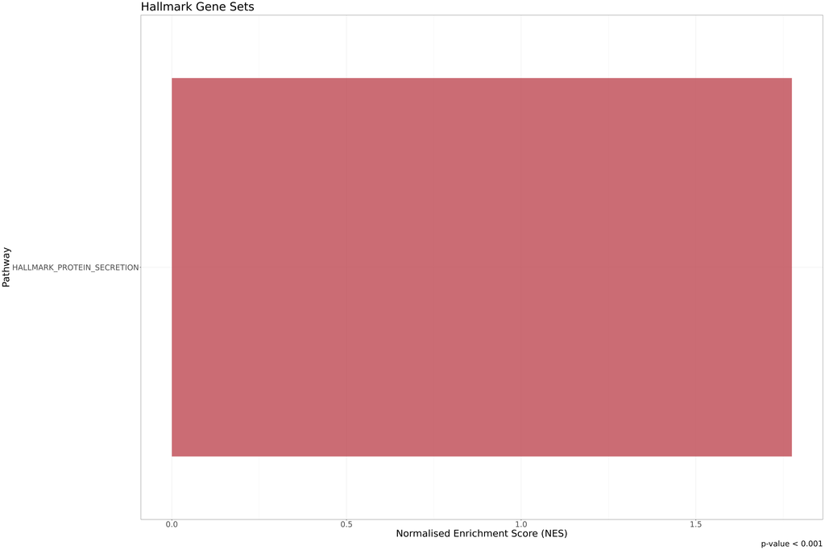

```r
hallmarks.res.tidy <- hallmarks.res %>%
  as_tibble() %>%
  arrange(desc(NES))

hallmarks.res.tidy %>%
  dplyr::select(-leadingEdge, -ES) %>%
  arrange(padj)

hallmark.sg.t <- hallmarks.res.tidy[,c(1,3,6)]
hallmark.sg.t <- as.data.frame(hallmark.sg.t)

#this small part is generic
thresh <- 0.001

#this one is no longer generic
data_to_plot <- hallmarks.res.tidy %>% filter(padj < thresh)

statvec <- c()
for (i in 1:nrow(data_to_plot)){
  if (data_to_plot[i,6] > 0){
    status <- "Upregulated"
  }
 else {
   status <- "Downregulated"
 }
statvec <- c(statvec, status)
}

data_to_plot$Status <- statvec

##-----HALMARK-----
gsea_plot_hall <- ggplot(data_to_plot, aes(reorder(pathway, NES), NES)) +
  geom_col(aes(fill= Status), alpha=0.75) + scale_fill_manual(values = c("#53A2BE","#BA3B46"), name = "Regulation Status", labels = c("Downregulated", "Upregulated"), breaks = c("Downregulated", "Upregulated")) +
  coord_flip() +
  labs(x="Pathway", y="Normalised Enrichment Score (NES)",
       title= "Hallmark Gene Sets",
       caption = paste0("p-value < ", thresh)) + theme(plot.title = element_text(hjust = 1)) +
  theme_bw() + theme(text=element_text(family = "Quicksand")) + theme(legend.position = "none")


gsea_plot_hall+
  theme(text=element_text(size=25,  family="Arial MS"))
```

## GSEA Length

Now, since SGs are enriched for longer transcripts, these pathways may simply be the ones which are tipically enriched in longer transcripts. Therefore, I will repeat the analysis, but using transcript lenght instead of t-statistic.

```r
#for all genes
DEGenes.HEK.SO <- DEGenes.HEK.SO[order(DEGenes.HEK.SO[,8]),]
gseatool <- DEGenes.HEK.SO[,8]
gseatool <- as.data.frame(gseatool)
colnames(gseatool)[1] <- "t"
gseatool[,2] <- DEGenes.HEK.SO$Gene
colnames(gseatool)[2] <- "Symbol"
gseatool <- gseatool[,c(2,1)]

#for only the genes without the contamination


vectorranks <- log10(gseatool$t)
vectorranks <- scale(vectorranks)
names(vectorranks) <- gseatool$Symbol


#to load our pathways

##-----HALLMARK-----
hallmarks.gs <- msigdbr(species = "Homo sapiens", collection = "H")

hallmarks.gsets <- hallmarks.gs %>% split(x = .$gene_symbol, f = .$gs_name)

for (set in names(hallmarks.gsets)){
  hallmarks.gsets[[set]] <- toupper(hallmarks.gsets[[set]])
}

hallmarks.res <- fgsea(pathways = hallmarks.gsets,
                       stats = vectorranks)
```

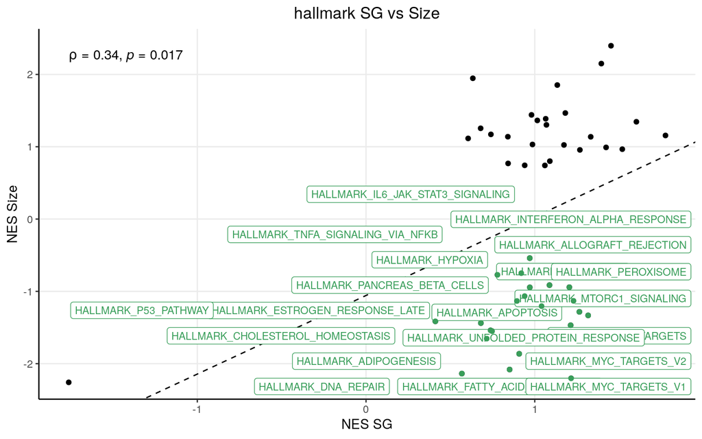

```r
hallmarks.res.tidy <- hallmarks.res %>%
  as_tibble() %>%
  arrange(desc(NES))

hallmarks.res.tidy %>%
  dplyr::select(-leadingEdge, -ES) %>%
  arrange(padj)

hallmark.size.t <- hallmarks.res.tidy[,c(1,3,6)]
hallmark.size.t <- as.data.frame(hallmark.size.t)


#HALLMARK
hallmark.scatter_ak <- merge(hallmark.sg.t, hallmark.size.t, by="pathway")
colnames(hallmark.scatter_ak) <- c("pathway", "sg_pval", "sg", "size_pval", "size")
hallmark.scatter_ak <- na.omit(hallmark.scatter_ak)
res_hallmark <- lm(size ~ sg, hallmark.scatter_ak)

vip.pathways_ak <- as.data.frame(hallmark.scatter_ak[(hallmark.scatter_ak$sg/hallmark.scatter_ak$size)<0,] )



ggplot(hallmark.scatter_ak, aes(x=sg, y=size)) + geom_point(color="black", alpha=01) +   theme_bw()+
 xlab("NES SG") + ylab("NES Size") +
  theme(axis.line = element_line(colour = "black"),
        panel.grid.minor = element_blank(),
        panel.border = element_blank(),
        panel.background = element_blank()) + ggtitle("hallmark SG vs Size")+
  theme(plot.title = element_text(hjust = 0.5)) +
  geom_abline(slope=res_hallmark$coefficients[2], intercept = res_hallmark$coefficients[1], linetype = "dashed") +
  geom_label_repel(vip.pathways_ak[1:ndegs,] , mapping=aes(label=vip.pathways_ak$pathway[1:ndegs]),size=3,point.padding=-0.5, color="#399e5a",max.overlaps = 200)+
  geom_point(data=vip.pathways_ak, aes(x=sg, y= size), color="#399e5a") + stat_cor(method = "spearman", cor.coef.name = "rho")
```

## Most altered pathways

I opted to see altered pathways as a whole. That is, ignoring bidirectionally and simply looking at what pathways are more altered as a whole (i.e, more expressed genes on either side).

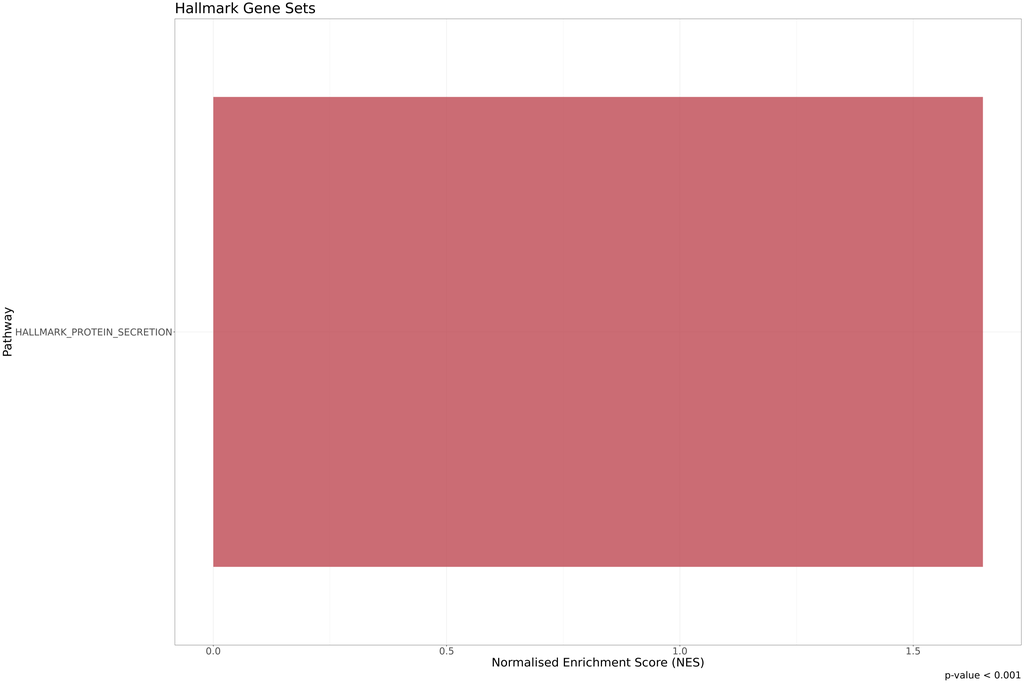

# Complex Linear Models

Now we must perform linear model fitting.

```r
mm <- model.matrix(~0+Biotype+StressType)
y <- voom(corrcounts_v1, mm)
fitted <- lmFit(y$E, mm)

head(coef(fitted))
```

```
##           BiotypeSG BiotypeVec BiotypeWC StressTypeH1 StressTypeH3
## 5_8S_rRNA  2.537623   3.467958  4.504183   1.41462810    1.6624786
## AAAS       5.949646   5.882373  6.373657  -0.41967767   -0.4909987
## AACS       5.299275   5.120636  5.185443   0.43549529    0.1147098
## AADAT      4.530905   4.394114  4.217315   0.07191174   -0.3694158
## AAGAB      6.832294   6.509248  5.804566   0.40099666    0.2145653
## AAK1       5.492556   5.313544  5.263629   0.34977338    0.3322331
##           StressTypeSorbitol StressTypeUnstressed
## 5_8S_rRNA          1.2631328          -0.86266743
## AAAS              -0.4045483          -0.02505054
## AACS              -0.2327278           0.28632686
## AADAT             -0.6058413          -0.03193401
## AAGAB              0.1911590          -0.04550958
## AAK1               0.5501933           0.72147600
```

```r
#next we measure contrasts between groups (log-fold change is obtained from these fitted linear models)
SG.vs.WC <- makeContrasts(BiotypeSG - BiotypeWC, levels = (colnames(coef(fitted))))
SG.vs.VEC <- makeContrasts(BiotypeSG - BiotypeVec, levels = (colnames(coef(fitted))))

#next we estimate the contrast for each gene
tmp.SG.vs.WC  <- contrasts.fit(fitted, SG.vs.WC )
tmp.SG.vs.VEC <- contrasts.fit(fitted, SG.vs.VEC)

#use empirical bayes smoothing of standard erros (shrinks extreme standard erros)
tmp.SG.vs.WC <- eBayes(tmp.SG.vs.WC)
tmp.SG.vs.VEC <- eBayes(tmp.SG.vs.VEC)

top.table.SG.vs.WC <- topTable(tmp.SG.vs.WC, sort.by = "logFC", n=Inf)
top.table.SG.vs.VEC <- topTable(tmp.SG.vs.VEC, sort.by = "logFC", n=Inf)

DEGenes.SG.vs.WC <- top.table.SG.vs.WC
DEGenes.SG.vs.VEC <- top.table.SG.vs.VEC




ndegs=20
```

# SG vs WC

## Volcano Plot

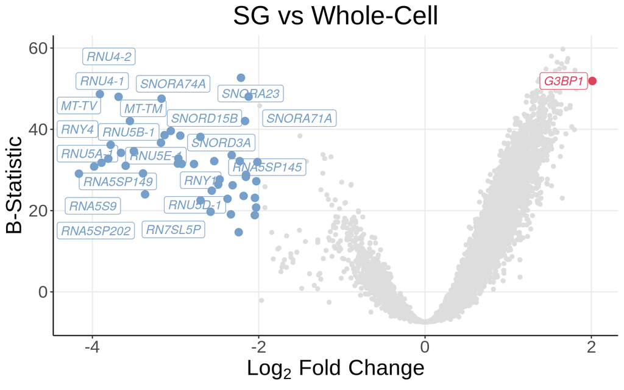

```r
write.table(x = DEGenes.SG.vs.WC,
          file = "~/Projects/StressGranules/SGPAPER/SGvsWC/CapSeq.txt", sep="\t", col.names = TRUE, row.names = TRUE, quote=FALSE)

upmarkers <- as.data.frame(DEGenes.SG.vs.WC[DEGenes.SG.vs.WC$logFC>2 & DEGenes.SG.vs.WC$adj.P.Val<0.05,] )
downmarkers <- as.data.frame(DEGenes.SG.vs.WC[DEGenes.SG.vs.WC$logFC< -2 & DEGenes.SG.vs.WC$adj.P.Val<0.05,] )


ggplot(data=DEGenes.SG.vs.WC,
                 aes(x=logFC,
                     y=  B)) +
  geom_point(color="#DDDDDD")+
  theme_bw() +
  theme(axis.line = element_line(colour = "black"),
        panel.grid.minor = element_blank(),
        panel.border = element_blank(),
        panel.background = element_blank()) +
  ggtitle("SG vs Whole-Cell")+
  theme(plot.title = element_text(hjust = 0.5)) +
  geom_label_repel(upmarkers[1:ndegs,] , mapping=aes(label=row.names(upmarkers)[1:ndegs]),size=4,point.padding=-0.5, color="#de425b",max.overlaps = 200, fontface="italic")+
  geom_label_repel(downmarkers[1:ndegs,] , mapping=aes(label=row.names(downmarkers)[1:ndegs]),size=4,point.padding=-0.5, color="#769fca",max.overlaps = 200, fontface="italic")+
  geom_point(data=upmarkers, aes(x=logFC, y=  B), color="#de425b", size=3)+
  geom_point(data=downmarkers, aes(x=logFC, y=  B), color="#769fca", size=3) + xlab(expression(Log[2] ~ Fold ~ Change)) + ylab("B-Statistic") + theme(text=element_text(family = "Arial", size = 20))
```

## Volcano Plot with Gene Lenght

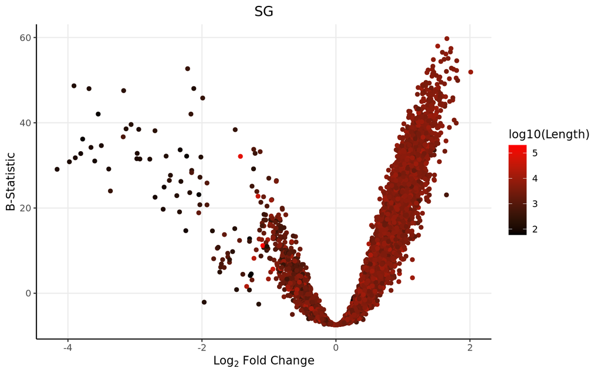

```r
DEGenes.SG.vs.WC$Gene <- row.names(DEGenes.SG.vs.WC)
colnames(genelength) <- c("Length","Gene")
DEGenes.SG.vs.WC <- merge(DEGenes.SG.vs.WC, genelength, by="Gene")

ggplot(data=DEGenes.SG.vs.WC,
                 aes(x=logFC,
                     y=  B)) +
  geom_point(aes(color=log10(Length)))+
  theme_bw() +
  theme(axis.line = element_line(colour = "black"),
        panel.grid.minor = element_blank(),
        panel.border = element_blank(),
        panel.background = element_blank()) +
  ggtitle("SG")+ xlab(expression(Log[2] ~ Fold ~ Change)) + ylab("B-Statistic") +
  theme(plot.title = element_text(hjust = 0.5))  +
  scale_colour_gradient(low = "black", high = "red")+ theme(text=element_text(family = "Quicksand"))
```

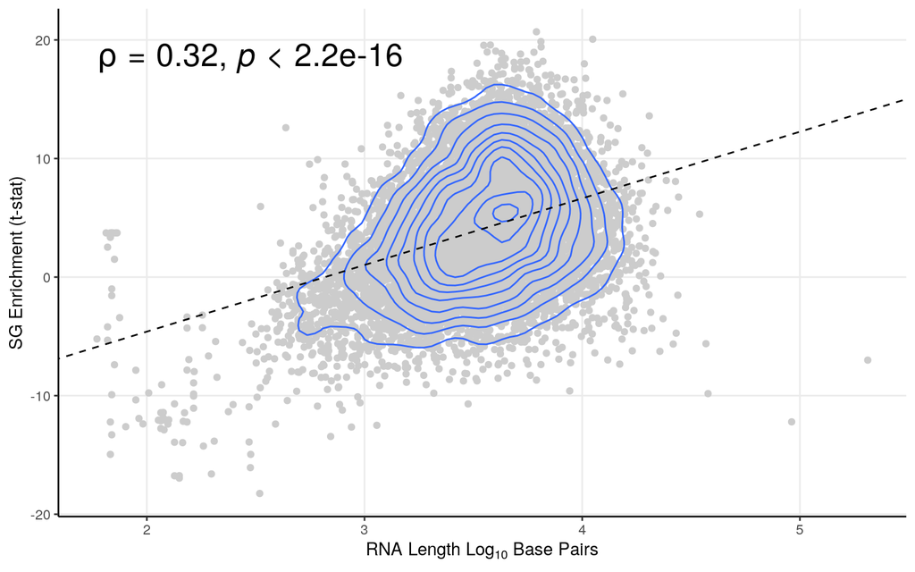

```r
smooth.SG <- lm(t~log10(Length), DEGenes.SG.vs.WC)
liner.SG <- rstandard(smooth.SG)
DEGenes.SG.vs.WC <-cbind(DEGenes.SG.vs.WC, liner.SG)
colnames(DEGenes.SG.vs.WC)[9] <- "Residuals"
row.names(DEGenes.SG.vs.WC) <- DEGenes.SG.vs.WC$Gene
linemarkers <- as.data.frame(DEGenes.SG.vs.WC[abs(DEGenes.SG.vs.WC$Residuals)>4,])

# Calculate the Spearman correlation coefficient
spearman_corr <- cor(DEGenes.SG.vs.WC$t, log10(DEGenes.SG.vs.WC$Length), method = "pearson")



ggplot(DEGenes.SG.vs.WC, aes(y=t, x=log10(Length))) + geom_point(color="#CCCCCC", alpha=1) +   theme_bw()+ geom_density_2d()+
 ylab("SG Enrichment (t-stat)") + xlab(expression(RNA ~ Length ~ Log[10] ~ Base ~ Pairs)) +
  theme(axis.line = element_line(colour = "black"),
        panel.grid.minor = element_blank(),
        panel.border = element_blank(),
        panel.background = element_blank()) +
  theme(plot.title = element_text(hjust = 0.5))  +
  geom_abline(slope=smooth.SG$coefficients[2], intercept = smooth.SG$coefficients[1], linetype = "dashed")+ stat_cor(method = "spearman", cor.coef.name = "rho",size=7)
```

We see a positive lenght bias.

## Expression Graphs (Extra QC)

As an added control, lets plot these genes in regard to their expression. This helps to see if the expression differences are robust, and not just driven by one sample.

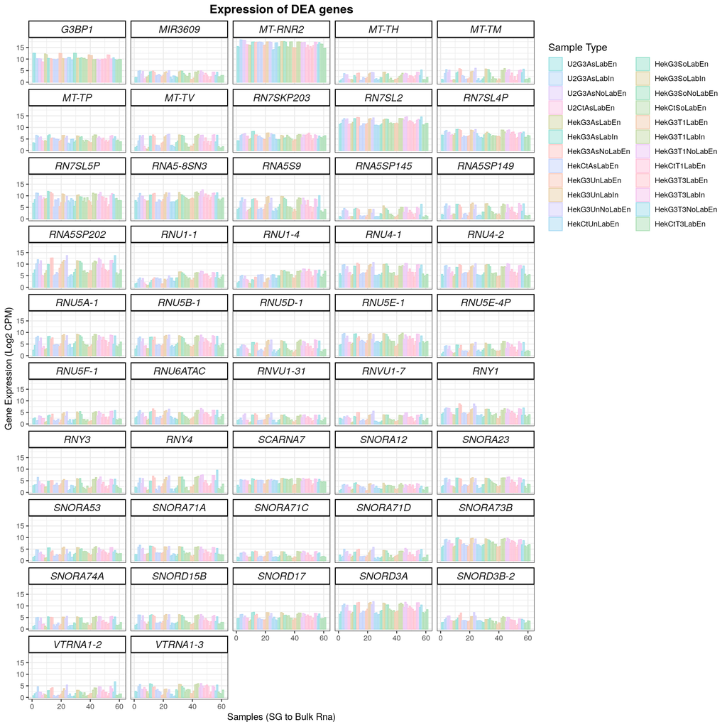

```r
# Define color palette
custom_palette <- qualitative_hcl(24, palette = "Pastel")
custom_palette <- sample(custom_palette, 24)

finagenes <- rbind(upmarkers, downmarkers)


dfforexpression <- dfforpca
samplecodes <- data.frame(samples=row.names(dfforexpression), purity=c(1:61))
sampletype <- data.frame(samples=row.names(dfforexpression), sampletype=SampleColouring)
dfforexpression <- t(dfforexpression)
genesforexp <- dfforexpression[row.names(dfforexpression)%in%row.names(finagenes),]
genesforexp <- reshape2::melt(genesforexp)
colnames(genesforexp) <- c("Gene", "samples", "expression")
genesforexp <- merge(genesforexp, samplecodes, by="samples")
genesforexp <- merge(genesforexp, sampletype, by="samples")
genesforexp <- genesforexp[,-1]
genesforexp[,2] <- as.numeric(genesforexp[,2])
genesforexp[,1] <- as.character(genesforexp[,1])
genesforexp <- genesforexp[order(genesforexp$Gene),]


winnyplot <- ggplot(genesforexp, aes(x=purity, y=expression, fill=sampletype, colour=sampletype)) + geom_bar(position="dodge", stat="identity", alpha=0.5) + facet_wrap(.~ Gene, ncol=5)
winnyplot <- winnyplot + scale_fill_manual(name = "Sample Type", values = custom_palette, breaks = unique(SampleColouring)) + scale_colour_manual(name = "Sample Type", values = custom_palette, breaks = unique(SampleColouring))
winnyplot <- winnyplot + theme_bw() + xlab("Samples (SG to Bulk Rna)") + ylab("Gene Expression (Log2 CPM)") + theme(
      strip.text.x = element_text(
        size = 12, face="italic"
        )) +
 theme(
   strip.background = element_rect(
     color="black", fill="#FFFFFF", size=1, linetype="solid"
     )
   ) + theme(
    #legend.position = c(.95, .40),
    legend.justification = c("right", "top"),
    legend.box.just = "right",
    ) + theme(legend.title = element_text(size = 12)) + ggtitle("Expression of DEA genes") + theme(plot.title = element_text(hjust = 0.5, size=14, face="bold"))
winnyplot
```

## GSEA Enrichment

Now that we have our genes of interest, it would also be interesting to see what are the **altered gene sets** between upregulated and downregulated transcripts from the above comparison. Therefore, lets perform a *Gene Set Enrichment Analysis*

```r
#for all genes
DEGenes.SG.vs.WC <- DEGenes.SG.vs.WC[order(DEGenes.SG.vs.WC[,4]),]
gseatool <- DEGenes.SG.vs.WC[,4]
gseatool <- as.data.frame(gseatool)
colnames(gseatool)[1] <- "t"
gseatool[,2] <- DEGenes.SG.vs.WC$Gene
colnames(gseatool)[2] <- "Symbol"
gseatool <- gseatool[,c(2,1)]

vectorranks <- gseatool$t
names(vectorranks) <- gseatool$Symbol


#to load our pathways
hallmarks.gs <- msigdbr(species = "Homo sapiens", collection =  "H")

hallmarks.gsets <- hallmarks.gs %>% split(x = .$gene_symbol, f = .$gs_name)

for (set in names(hallmarks.gsets)){
  hallmarks.gsets[[set]] <- toupper(hallmarks.gsets[[set]])
}

hallmarks.res <- fgsea(pathways = hallmarks.gsets,
                       stats = vectorranks)
```

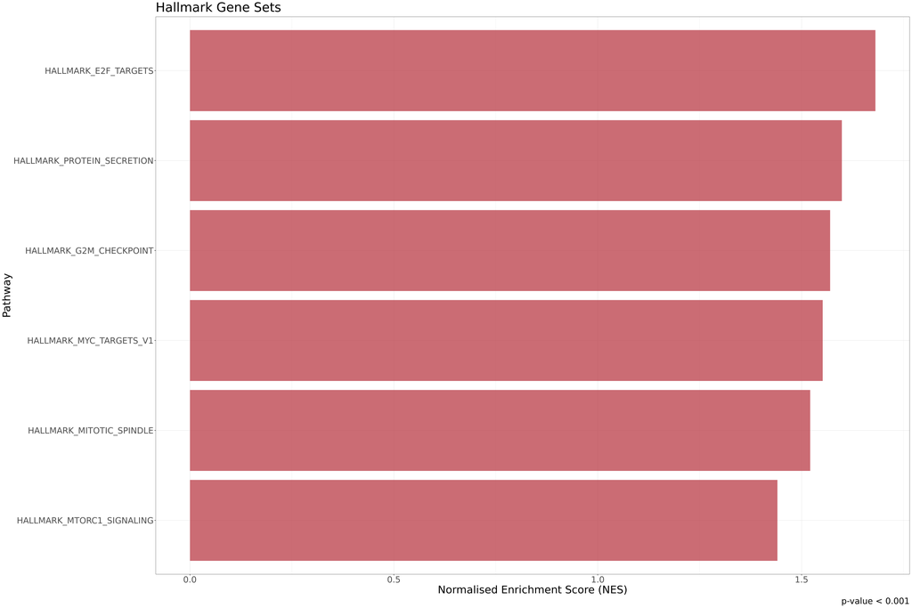

```r
hallmarks.res.tidy <- hallmarks.res %>%
  as_tibble() %>%
  arrange(desc(NES))

hallmarks.res.tidy %>%
  dplyr::select(-leadingEdge, -ES) %>%
  arrange(padj)

hallmark.sg.t <- hallmarks.res.tidy[,c(1,3,6)]
hallmark.sg.t <- as.data.frame(hallmark.sg.t)

#this small part is generic
thresh <- 0.001

#this one is no longer generic
data_to_plot <- hallmarks.res.tidy %>% filter(padj < thresh)

statvec <- c()
for (i in 1:nrow(data_to_plot)){
  if (data_to_plot[i,6] > 0){
    status <- "Upregulated"
  }
 else {
   status <- "Downregulated"
 }
statvec <- c(statvec, status)
}

data_to_plot$Status <- statvec

##-----HALMARK-----
gsea_plot_hall <- ggplot(data_to_plot, aes(reorder(pathway, NES), NES)) +
  geom_col(aes(fill= Status), alpha=0.75) + scale_fill_manual(values = c("#53A2BE","#BA3B46"), name = "Regulation Status", labels = c("Downregulated", "Upregulated"), breaks = c("Downregulated", "Upregulated")) +
  coord_flip() +
  labs(x="Pathway", y="Normalised Enrichment Score (NES)",
       title= "Hallmark Gene Sets",
       caption = paste0("p-value < ", thresh)) + theme(plot.title = element_text(hjust = 1)) +
  theme_bw() + theme(text=element_text(family = "Quicksand")) + theme(legend.position = "none")


gsea_plot_hall+
  theme(text=element_text(size=25,  family="Arial MS"))
```

## GSEA Length

Now, since SGs are enriched for longer transcripts, these pathways may simply be the ones which are tipically enriched in longer transcripts. Therefore, I will repeat the analysis, but using transcript lenght instead of t-statistic.

```r
#for all genes
DEGenes.SG.vs.WC <- DEGenes.SG.vs.WC[order(DEGenes.SG.vs.WC[,8]),]
gseatool <- DEGenes.SG.vs.WC[,8]
gseatool <- as.data.frame(gseatool)
colnames(gseatool)[1] <- "t"
gseatool[,2] <- DEGenes.SG.vs.WC$Gene
colnames(gseatool)[2] <- "Symbol"
gseatool <- gseatool[,c(2,1)]

#for only the genes without the contamination


vectorranks <- log10(gseatool$t)
vectorranks <- scale(vectorranks)
names(vectorranks) <- gseatool$Symbol


#to load our pathways

##-----HALLMARK-----
hallmarks.gs <- msigdbr(species = "Homo sapiens", collection = "H")

hallmarks.gsets <- hallmarks.gs %>% split(x = .$gene_symbol, f = .$gs_name)

for (set in names(hallmarks.gsets)){
  hallmarks.gsets[[set]] <- toupper(hallmarks.gsets[[set]])
}

hallmarks.res <- fgsea(pathways = hallmarks.gsets,
                       stats = vectorranks)
```

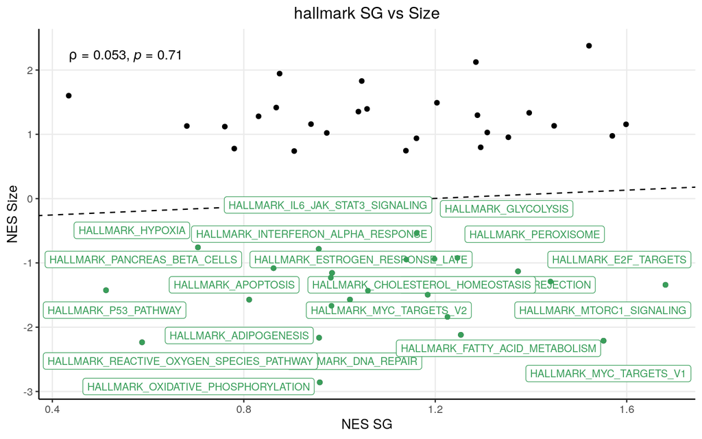

```r
hallmarks.res.tidy <- hallmarks.res %>%
  as_tibble() %>%
  arrange(desc(NES))

hallmarks.res.tidy %>%
  dplyr::select(-leadingEdge, -ES) %>%
  arrange(padj)

hallmark.size.t <- hallmarks.res.tidy[,c(1,3,6)]
hallmark.size.t <- as.data.frame(hallmark.size.t)


#HALLMARK
hallmark.scatter_ak <- merge(hallmark.sg.t, hallmark.size.t, by="pathway")
colnames(hallmark.scatter_ak) <- c("pathway", "sg_pval", "sg", "size_pval", "size")
hallmark.scatter_ak <- na.omit(hallmark.scatter_ak)
res_hallmark <- lm(size ~ sg, hallmark.scatter_ak)

vip.pathways_ak <- as.data.frame(hallmark.scatter_ak[(hallmark.scatter_ak$sg/hallmark.scatter_ak$size)<0,] )



ggplot(hallmark.scatter_ak, aes(x=sg, y=size)) + geom_point(color="black", alpha=01) +   theme_bw()+
 xlab("NES SG") + ylab("NES Size") +
  theme(axis.line = element_line(colour = "black"),
        panel.grid.minor = element_blank(),
        panel.border = element_blank(),
        panel.background = element_blank()) + ggtitle("hallmark SG vs Size")+
  theme(plot.title = element_text(hjust = 0.5)) +
  geom_abline(slope=res_hallmark$coefficients[2], intercept = res_hallmark$coefficients[1], linetype = "dashed") +
  geom_label_repel(vip.pathways_ak[1:ndegs,] , mapping=aes(label=vip.pathways_ak$pathway[1:ndegs]),size=3,point.padding=-0.5, color="#399e5a",max.overlaps = 200)+
  geom_point(data=vip.pathways_ak, aes(x=sg, y= size), color="#399e5a") + stat_cor(method = "spearman", cor.coef.name = "rho")
```

Even though there is some lenght bias in terms of enrichment, it does not seem to be linked in terms of gene set enrichment.

## Most altered pathways

I opted to see altered pathways as a whole. That is, ignoring bidirectionally and simply looking at what pathways are more altered as a whole (i.e, more expressed genes on either side).

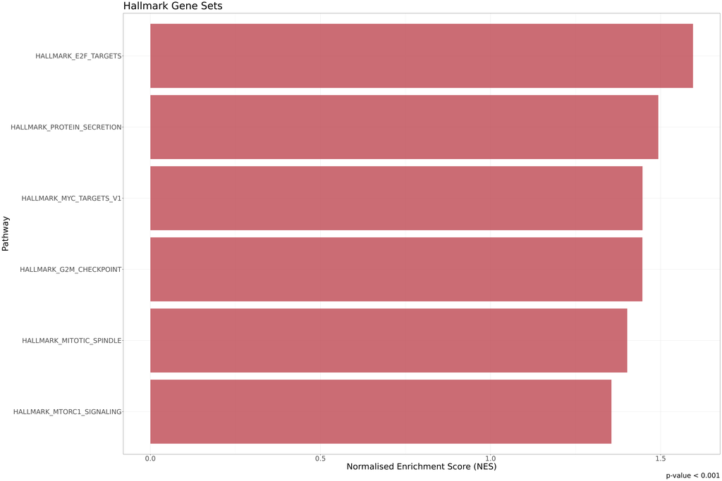

# SG vs VEC

## Volcano Plot

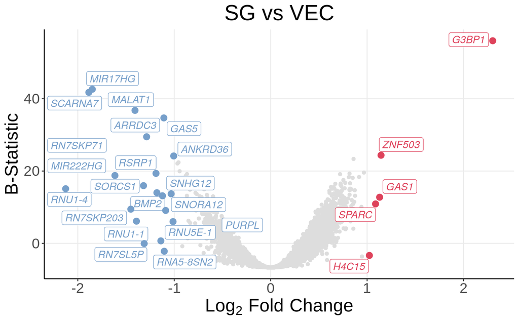

```r
upmarkers <- as.data.frame(DEGenes.SG.vs.VEC[DEGenes.SG.vs.VEC$logFC>1 & DEGenes.SG.vs.VEC$adj.P.Val<0.05,] )
downmarkers <- as.data.frame(DEGenes.SG.vs.VEC[DEGenes.SG.vs.VEC$logFC< -1 & DEGenes.SG.vs.VEC$adj.P.Val<0.05,] )


ggplot(data=DEGenes.SG.vs.VEC,
                 aes(x=logFC,
                     y=  B)) +
  geom_point(color="#DDDDDD")+
  theme_bw() +
  theme(axis.line = element_line(colour = "black"),
        panel.grid.minor = element_blank(),
        panel.border = element_blank(),
        panel.background = element_blank()) +
  ggtitle("SG vs VEC")+
  theme(plot.title = element_text(hjust = 0.5)) +
  geom_label_repel(upmarkers[1:ndegs,] , mapping=aes(label=row.names(upmarkers)[1:ndegs]),size=4,point.padding=-0.5, color="#de425b",max.overlaps = 200, fontface="italic")+
  geom_label_repel(downmarkers[1:ndegs,] , mapping=aes(label=row.names(downmarkers)[1:ndegs]),size=4,point.padding=-0.5, color="#769fca",max.overlaps = 200, fontface="italic")+
  geom_point(data=upmarkers, aes(x=logFC, y=  B), color="#de425b", size=3)+
  geom_point(data=downmarkers, aes(x=logFC, y=  B), color="#769fca", size=3) + xlab(expression(Log[2] ~ Fold ~ Change)) + ylab("B-Statistic") + theme(text=element_text(family = "Arial", size = 20))
```

## Volcano Plot with Gene Lenght

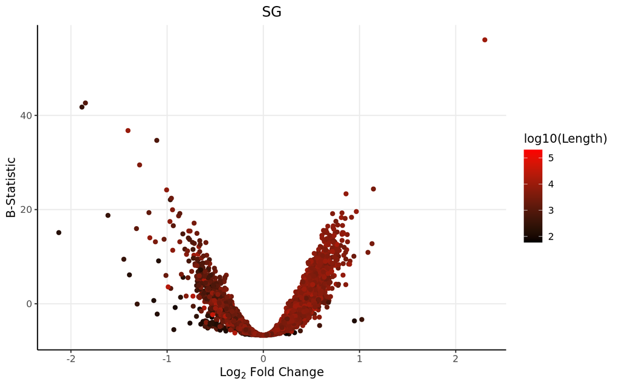

```r
DEGenes.SG.vs.VEC$Gene <- row.names(DEGenes.SG.vs.VEC)
colnames(genelength) <- c("Length","Gene")
DEGenes.SG.vs.VEC <- merge(DEGenes.SG.vs.VEC, genelength, by="Gene")

ggplot(data=DEGenes.SG.vs.VEC,
                 aes(x=logFC,
                     y=  B)) +
  geom_point(aes(color=log10(Length)))+
  theme_bw() +
  theme(axis.line = element_line(colour = "black"),
        panel.grid.minor = element_blank(),
        panel.border = element_blank(),
        panel.background = element_blank()) +
  ggtitle("SG")+ xlab(expression(Log[2] ~ Fold ~ Change)) + ylab("B-Statistic") +
  theme(plot.title = element_text(hjust = 0.5))  +
  scale_colour_gradient(low = "black", high = "red")+ theme(text=element_text(family = "Quicksand"))
```

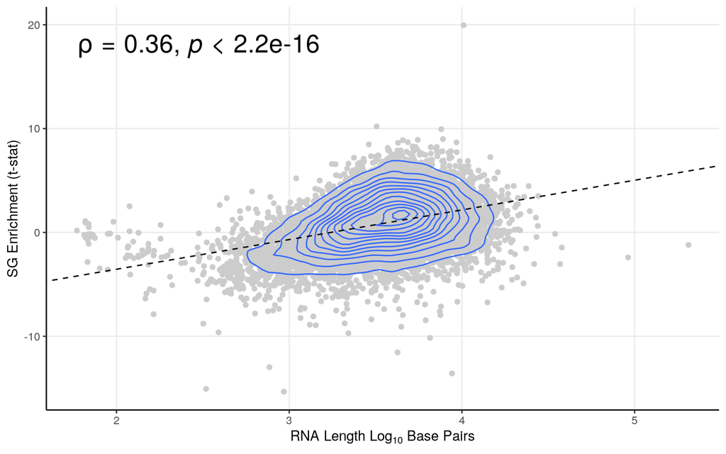

```r
smooth.SG <- lm(t~log10(Length), DEGenes.SG.vs.VEC)
liner.SG <- rstandard(smooth.SG)
DEGenes.SG.vs.VEC <-cbind(DEGenes.SG.vs.VEC, liner.SG)
colnames(DEGenes.SG.vs.VEC)[9] <- "Residuals"
row.names(DEGenes.SG.vs.VEC) <- DEGenes.SG.vs.VEC$Gene
linemarkers <- as.data.frame(DEGenes.SG.vs.VEC[abs(DEGenes.SG.vs.VEC$Residuals)>4,])

# Calculate the Spearman correlation coefficient
spearman_corr <- cor(DEGenes.SG.vs.VEC$t, log10(DEGenes.SG.vs.VEC$Length), method = "pearson")



ggplot(DEGenes.SG.vs.VEC, aes(y=t, x=log10(Length))) + geom_point(color="#CCCCCC", alpha=1) +   theme_bw()+ geom_density_2d()+
 ylab("SG Enrichment (t-stat)") + xlab(expression(RNA ~ Length ~ Log[10] ~ Base ~ Pairs)) +
  theme(axis.line = element_line(colour = "black"),
        panel.grid.minor = element_blank(),
        panel.border = element_blank(),
        panel.background = element_blank()) +
  theme(plot.title = element_text(hjust = 0.5))  +
  geom_abline(slope=smooth.SG$coefficients[2], intercept = smooth.SG$coefficients[1], linetype = "dashed")+ stat_cor(method = "spearman", cor.coef.name = "rho",size=7)
```

We see a positive lenght bias.

## Expression Graphs (Extra QC)

As an added control, lets plot these genes in regard to their expression. This helps to see if the expression differences are robust, and not just driven by one sample.

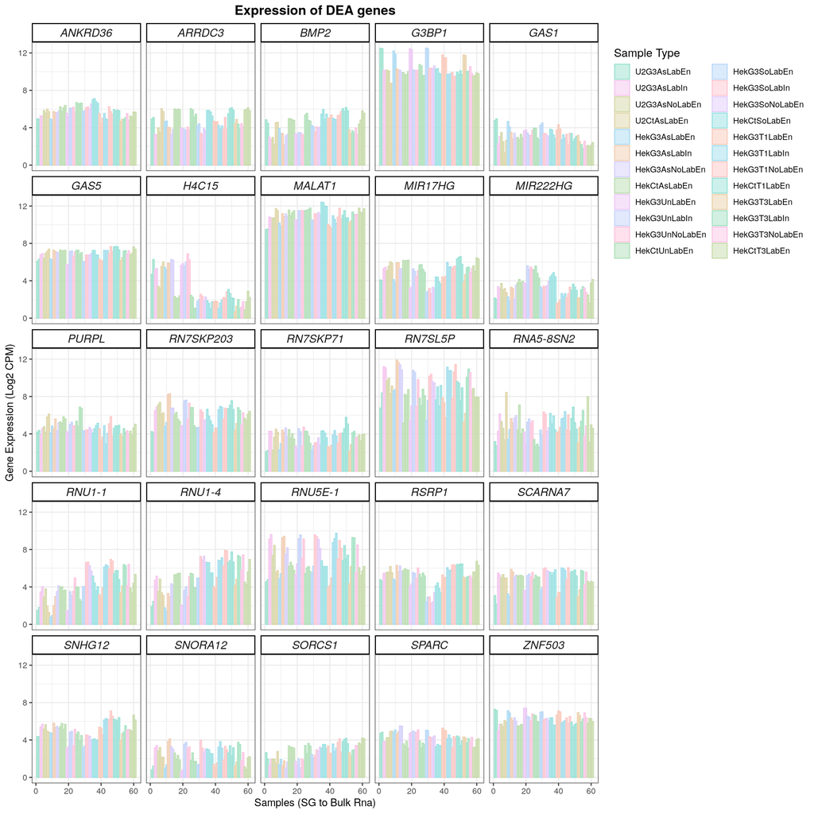

```r
# Define color palette
custom_palette <- qualitative_hcl(24, palette = "Pastel")
custom_palette <- sample(custom_palette, 24)

finagenes <- rbind(upmarkers, downmarkers)


dfforexpression <- dfforpca
samplecodes <- data.frame(samples=row.names(dfforexpression), purity=c(1:61))
sampletype <- data.frame(samples=row.names(dfforexpression), sampletype=SampleColouring)
dfforexpression <- t(dfforexpression)
genesforexp <- dfforexpression[row.names(dfforexpression)%in%row.names(finagenes),]
genesforexp <- reshape2::melt(genesforexp)
colnames(genesforexp) <- c("Gene", "samples", "expression")
genesforexp <- merge(genesforexp, samplecodes, by="samples")
genesforexp <- merge(genesforexp, sampletype, by="samples")
genesforexp <- genesforexp[,-1]
genesforexp[,2] <- as.numeric(genesforexp[,2])
genesforexp[,1] <- as.character(genesforexp[,1])
genesforexp <- genesforexp[order(genesforexp$Gene),]


winnyplot <- ggplot(genesforexp, aes(x=purity, y=expression, fill=sampletype, colour=sampletype)) + geom_bar(position="dodge", stat="identity", alpha=0.5) + facet_wrap(.~ Gene, ncol=5)
winnyplot <- winnyplot + scale_fill_manual(name = "Sample Type", values = custom_palette, breaks = unique(SampleColouring)) + scale_colour_manual(name = "Sample Type", values = custom_palette, breaks = unique(SampleColouring))
winnyplot <- winnyplot + theme_bw() + xlab("Samples (SG to Bulk Rna)") + ylab("Gene Expression (Log2 CPM)") + theme(
      strip.text.x = element_text(
        size = 12, face="italic"
        )) +
 theme(
   strip.background = element_rect(
     color="black", fill="#FFFFFF", size=1, linetype="solid"
     )
   ) + theme(
    #legend.position = c(.95, .40),
    legend.justification = c("right", "top"),
    legend.box.just = "right",
    ) + theme(legend.title = element_text(size = 12)) + ggtitle("Expression of DEA genes") + theme(plot.title = element_text(hjust = 0.5, size=14, face="bold"))
winnyplot
```

## GSEA Enrichment

Now that we have our genes of interest, it would also be interesting to see what are the **altered gene sets** between upregulated and downregulated transcripts from the above comparison. Therefore, lets perform a *Gene Set Enrichment Analysis*

```r
#for all genes
DEGenes.SG.vs.VEC <- DEGenes.SG.vs.VEC[order(DEGenes.SG.vs.VEC[,4]),]
gseatool <- DEGenes.SG.vs.VEC[,4]
gseatool <- as.data.frame(gseatool)
colnames(gseatool)[1] <- "t"
gseatool[,2] <- DEGenes.SG.vs.VEC$Gene
colnames(gseatool)[2] <- "Symbol"
gseatool <- gseatool[,c(2,1)]

vectorranks <- gseatool$t
names(vectorranks) <- gseatool$Symbol


#to load our pathways
hallmarks.gs <- msigdbr(species = "Homo sapiens", collection =  "H")

hallmarks.gsets <- hallmarks.gs %>% split(x = .$gene_symbol, f = .$gs_name)

for (set in names(hallmarks.gsets)){
  hallmarks.gsets[[set]] <- toupper(hallmarks.gsets[[set]])
}

hallmarks.res <- fgsea(pathways = hallmarks.gsets,
                       stats = vectorranks)
```

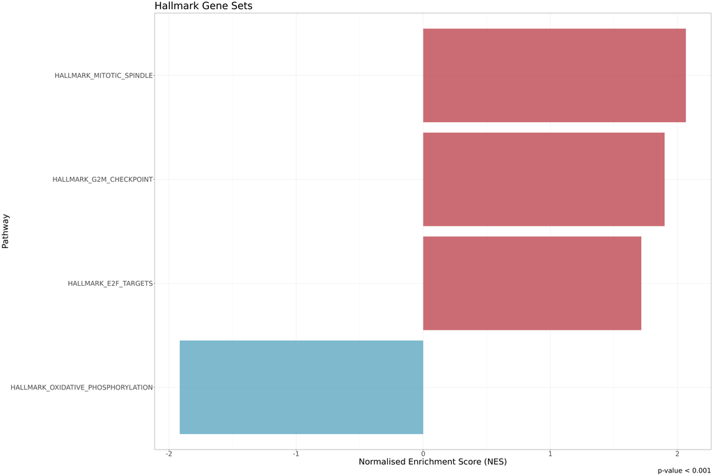

```r
hallmarks.res.tidy <- hallmarks.res %>%
  as_tibble() %>%
  arrange(desc(NES))

hallmarks.res.tidy %>%
  dplyr::select(-leadingEdge, -ES) %>%
  arrange(padj)

hallmark.sg.t <- hallmarks.res.tidy[,c(1,3,6)]
hallmark.sg.t <- as.data.frame(hallmark.sg.t)

#this small part is generic
thresh <- 0.001

#this one is no longer generic
data_to_plot <- hallmarks.res.tidy %>% filter(padj < thresh)

statvec <- c()
for (i in 1:nrow(data_to_plot)){
  if (data_to_plot[i,6] > 0){
    status <- "Upregulated"
  }
 else {
   status <- "Downregulated"
 }
statvec <- c(statvec, status)
}

data_to_plot$Status <- statvec

##-----HALMARK-----
gsea_plot_hall <- ggplot(data_to_plot, aes(reorder(pathway, NES), NES)) +
  geom_col(aes(fill= Status), alpha=0.75) + scale_fill_manual(values = c("#53A2BE","#BA3B46"), name = "Regulation Status", labels = c("Downregulated", "Upregulated"), breaks = c("Downregulated", "Upregulated")) +
  coord_flip() +
  labs(x="Pathway", y="Normalised Enrichment Score (NES)",
       title= "Hallmark Gene Sets",
       caption = paste0("p-value < ", thresh)) + theme(plot.title = element_text(hjust = 1)) +
  theme_bw() + theme(text=element_text(family = "Quicksand")) + theme(legend.position = "none")


gsea_plot_hall+
  theme(text=element_text(size=25,  family="Arial MS"))
```

## GSEA Length

Now, since SGs are enriched for longer transcripts, these pathways may simply be the ones which are tipically enriched in longer transcripts. Therefore, I will repeat the analysis, but using transcript lenght instead of t-statistic.

```r
#for all genes
DEGenes.SG.vs.VEC <- DEGenes.SG.vs.VEC[order(DEGenes.SG.vs.VEC[,8]),]
gseatool <- DEGenes.SG.vs.VEC[,8]
gseatool <- as.data.frame(gseatool)
colnames(gseatool)[1] <- "t"
gseatool[,2] <- DEGenes.SG.vs.VEC$Gene
colnames(gseatool)[2] <- "Symbol"
gseatool <- gseatool[,c(2,1)]

#for only the genes without the contamination


vectorranks <- log10(gseatool$t)
vectorranks <- scale(vectorranks)
names(vectorranks) <- gseatool$Symbol


#to load our pathways

##-----HALLMARK-----
hallmarks.gs <- msigdbr(species = "Homo sapiens", collection = "H")

hallmarks.gsets <- hallmarks.gs %>% split(x = .$gene_symbol, f = .$gs_name)

for (set in names(hallmarks.gsets)){
  hallmarks.gsets[[set]] <- toupper(hallmarks.gsets[[set]])
}

hallmarks.res <- fgsea(pathways = hallmarks.gsets,
                       stats = vectorranks)
```

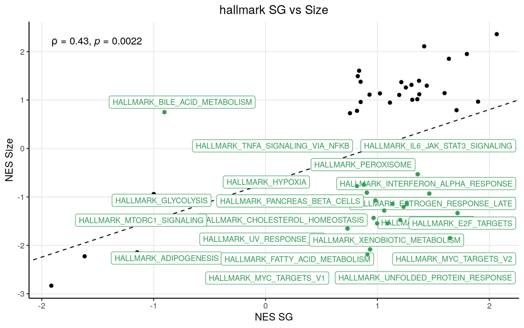

```r
hallmarks.res.tidy <- hallmarks.res %>%
  as_tibble() %>%
  arrange(desc(NES))

hallmarks.res.tidy %>%
  dplyr::select(-leadingEdge, -ES) %>%
  arrange(padj)

hallmark.size.t <- hallmarks.res.tidy[,c(1,3,6)]
hallmark.size.t <- as.data.frame(hallmark.size.t)


#HALLMARK
hallmark.scatter_ak <- merge(hallmark.sg.t, hallmark.size.t, by="pathway")
colnames(hallmark.scatter_ak) <- c("pathway", "sg_pval", "sg", "size_pval", "size")
hallmark.scatter_ak <- na.omit(hallmark.scatter_ak)
res_hallmark <- lm(size ~ sg, hallmark.scatter_ak)

vip.pathways_ak <- as.data.frame(hallmark.scatter_ak[(hallmark.scatter_ak$sg/hallmark.scatter_ak$size)<0,] )



ggplot(hallmark.scatter_ak, aes(x=sg, y=size)) + geom_point(color="black", alpha=01) +   theme_bw()+
 xlab("NES SG") + ylab("NES Size") +
  theme(axis.line = element_line(colour = "black"),
        panel.grid.minor = element_blank(),
        panel.border = element_blank(),
        panel.background = element_blank()) + ggtitle("hallmark SG vs Size")+
  theme(plot.title = element_text(hjust = 0.5)) +
  geom_abline(slope=res_hallmark$coefficients[2], intercept = res_hallmark$coefficients[1], linetype = "dashed") +
  geom_label_repel(vip.pathways_ak[1:ndegs,] , mapping=aes(label=vip.pathways_ak$pathway[1:ndegs]),size=3,point.padding=-0.5, color="#399e5a",max.overlaps = 200)+
  geom_point(data=vip.pathways_ak, aes(x=sg, y= size), color="#399e5a") + stat_cor(method = "spearman", cor.coef.name = "rho")
```

Even though there is some lenght bias in terms of enrichment, this time it does seem to be linked with gene set enrichment

## Most altered pathways

I opted to see altered pathways as a whole. That is, ignoring bidirectionally and simply looking at what pathways are more altered as a whole (i.e, more expressed genes on either side).

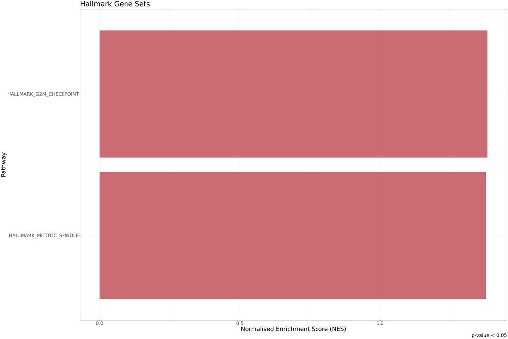

# Final Version

```r
StressType <- c(rep("Stress",18),rep("Unstressed",10),rep("Stress",10),rep("Recovering",13),rep("Recovering",10))

Biotype <- c(rep("SG",2),rep("WC",4),rep("Vec",2), #U2
             rep("SG",2),rep("WC",4),rep("Vec",4), #HekAs
             rep("SG",2),rep("WC",4),rep("Vec",4), #HekUn
             rep("SG",2),rep("WC",4),rep("Vec",4), #HekSo
             rep("SG",3),rep("WC",6),rep("Vec",4),
             rep("SG",2),rep("WC",4),rep("Vec",4))
# Relevel factor with "Vec" first
Biotype <- factor(Biotype, levels = c("Vec", "SG", "WC"))

mm <- model.matrix(~1+Biotype*StressType)
y <- voom(corrcounts_v1, mm)
fitted <- lmFit(y$E, mm)

head(coef(fitted))
```

```
##           (Intercept)   BiotypeSG   BiotypeWC StressTypeStress
## 5_8S_rRNA    5.611023 -1.86958592  0.07829542      -1.79148297
## AAAS         5.564390 -0.11348808  0.27644502       0.09501903
## AACS         5.523677  0.06673933 -0.12538491      -0.51103103
## AADAT        4.315891  0.09022590 -0.24953401      -0.14418495
## AAGAB        6.810884  0.31641669 -0.65926948      -0.26779253
## AAK1         5.488140  0.26135932  0.29427840       0.24779011
##           StressTypeUnstressed BiotypeSG:StressTypeStress
## 5_8S_rRNA           -3.8305795                  1.0577735
## AAAS                 0.1710820                  0.2001610
## AACS                -0.3353456                  0.1129889
## AADAT               -0.1445889                  0.2868707
## AAGAB               -0.2283065                  0.1277437
## AAK1                 0.3739193                 -0.2838541
##           BiotypeWC:StressTypeStress BiotypeSG:StressTypeUnstressed
## 5_8S_rRNA                 1.13092020                      2.3917969
## AAAS                      0.38826389                      0.6351010
## AACS                      0.24768305                      0.4586012
## AADAT                    -0.03333356                     -0.3716656
## AAGAB                    -0.02563894                     -0.3073812
## AAK1                     -0.77051384                      0.1927018
##           BiotypeWC:StressTypeUnstressed
## 5_8S_rRNA                      2.2937734
## AAAS                           0.2922943
## AACS                           0.5634185
## AADAT                          0.7590452
## AAGAB                         -0.1855052
## AAK1                          -0.0493170
```

```r
#use empirical bayes smoothing of standard erros (shrinks extreme standard erros)
tmp.SG.vs.VEC <- eBayes(fitted)

top.table.SG.vs.VEC <- topTable(tmp.SG.vs.VEC, 5, sort.by = "logFC", n=Inf)

DEGenes.SG.vs.VEC <- top.table.SG.vs.VEC




ndegs=20
```

## Volcano Plot

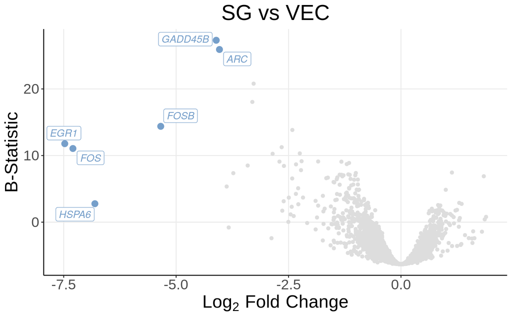

```r
write.table(x = DEGenes.SG.vs.VEC,
          file = "~/Projects/StressGranules/SGPAPER/RealSGs/CapSeq.txt", sep="\t", col.names = TRUE, row.names = TRUE, quote=FALSE)

upmarkers <- as.data.frame(DEGenes.SG.vs.VEC[DEGenes.SG.vs.VEC$logFC>4 & DEGenes.SG.vs.VEC$adj.P.Val<0.05,] )
downmarkers <- as.data.frame(DEGenes.SG.vs.VEC[DEGenes.SG.vs.VEC$logFC< -4 & DEGenes.SG.vs.VEC$adj.P.Val<0.05,] )


ggplot(data=DEGenes.SG.vs.VEC,
                 aes(x=logFC,
                     y=  B)) +
  geom_point(color="#DDDDDD")+
  theme_bw() +
  theme(axis.line = element_line(colour = "black"),
        panel.grid.minor = element_blank(),
        panel.border = element_blank(),
        panel.background = element_blank()) +
  ggtitle("SG vs VEC")+
  theme(plot.title = element_text(hjust = 0.5)) +
  geom_label_repel(upmarkers[1:ndegs,] , mapping=aes(label=row.names(upmarkers)[1:ndegs]),size=4,point.padding=-0.5, color="#de425b",max.overlaps = 200, fontface="italic")+
  geom_label_repel(downmarkers[1:ndegs,] , mapping=aes(label=row.names(downmarkers)[1:ndegs]),size=4,point.padding=-0.5, color="#769fca",max.overlaps = 200, fontface="italic")+
  geom_point(data=upmarkers, aes(x=logFC, y=  B), color="#de425b", size=3)+
  geom_point(data=downmarkers, aes(x=logFC, y=  B), color="#769fca", size=3) + xlab(expression(Log[2] ~ Fold ~ Change)) + ylab("B-Statistic") + theme(text=element_text(family = "Arial", size = 20))
```

## Volcano Plot with Gene Lenght

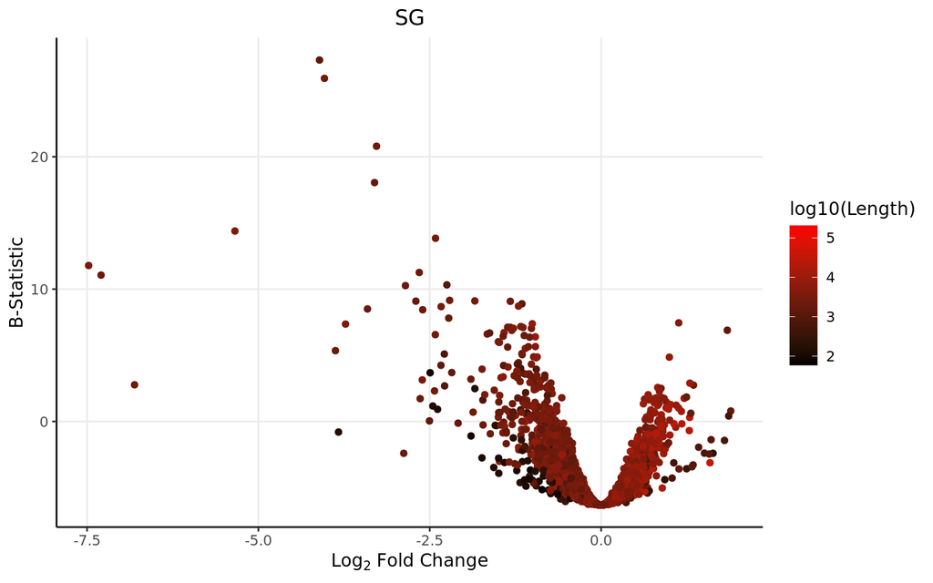

```r
DEGenes.SG.vs.VEC$Gene <- row.names(DEGenes.SG.vs.VEC)
colnames(genelength) <- c("Length","Gene")
DEGenes.SG.vs.VEC <- merge(DEGenes.SG.vs.VEC, genelength, by="Gene")

ggplot(data=DEGenes.SG.vs.VEC,
                 aes(x=logFC,
                     y=  B)) +
  geom_point(aes(color=log10(Length)))+
  theme_bw() +
  theme(axis.line = element_line(colour = "black"),
        panel.grid.minor = element_blank(),
        panel.border = element_blank(),
        panel.background = element_blank()) +
  ggtitle("SG")+ xlab(expression(Log[2] ~ Fold ~ Change)) + ylab("B-Statistic") +
  theme(plot.title = element_text(hjust = 0.5))  +
  scale_colour_gradient(low = "black", high = "red")+ theme(text=element_text(family = "Quicksand"))
```

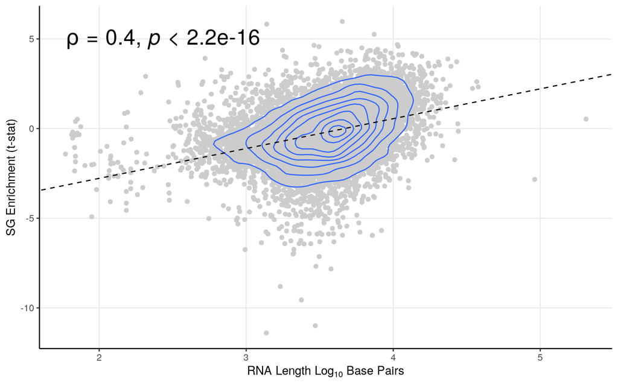

```r
smooth.SG <- lm(t~log10(Length), DEGenes.SG.vs.VEC)
liner.SG <- rstandard(smooth.SG)
DEGenes.SG.vs.VEC <-cbind(DEGenes.SG.vs.VEC, liner.SG)
colnames(DEGenes.SG.vs.VEC)[9] <- "Residuals"
row.names(DEGenes.SG.vs.VEC) <- DEGenes.SG.vs.VEC$Gene
linemarkers <- as.data.frame(DEGenes.SG.vs.VEC[abs(DEGenes.SG.vs.VEC$Residuals)>4,])

# Calculate the Spearman correlation coefficient
spearman_corr <- cor(DEGenes.SG.vs.VEC$t, log10(DEGenes.SG.vs.VEC$Length), method = "pearson")



ggplot(DEGenes.SG.vs.VEC, aes(y=t, x=log10(Length))) + geom_point(color="#CCCCCC", alpha=1) +   theme_bw()+ geom_density_2d()+
 ylab("SG Enrichment (t-stat)") + xlab(expression(RNA ~ Length ~ Log[10] ~ Base ~ Pairs)) +
  theme(axis.line = element_line(colour = "black"),
        panel.grid.minor = element_blank(),
        panel.border = element_blank(),
        panel.background = element_blank()) +
  theme(plot.title = element_text(hjust = 0.5))  +
  geom_abline(slope=smooth.SG$coefficients[2], intercept = smooth.SG$coefficients[1], linetype = "dashed")+ stat_cor(method = "spearman", cor.coef.name = "rho",size=7)
```

### GSEA Enrichment

Now that we have our genes of interest, it would also be interesting to see what are the **altered gene sets** between upregulated and downregulated transcripts from the above comparison. Therefore, lets perform a *Gene Set Enrichment Analysis*

```r
#for all genes
DEGenes.SG.vs.VEC <- DEGenes.SG.vs.VEC[order(DEGenes.SG.vs.VEC[,4]),]
gseatool <- DEGenes.SG.vs.VEC[,4]
gseatool <- as.data.frame(gseatool)
colnames(gseatool)[1] <- "t"
gseatool[,2] <- DEGenes.SG.vs.VEC$Gene
colnames(gseatool)[2] <- "Symbol"
gseatool <- gseatool[,c(2,1)]

vectorranks <- gseatool$t
names(vectorranks) <- gseatool$Symbol

### CELL COMPONENT

#to load our pathways
hallmarks.gs <- msigdbr(species = "Homo sapiens", collection =  "C5", subcollection = "GO:CC")

hallmarks.gsets <- hallmarks.gs %>% split(x = .$gene_symbol, f = .$gs_name)

for (set in names(hallmarks.gsets)){
  hallmarks.gsets[[set]] <- toupper(hallmarks.gsets[[set]])
}

hallmarks.res <- fgsea(pathways = hallmarks.gsets,
                       stats = vectorranks)
```

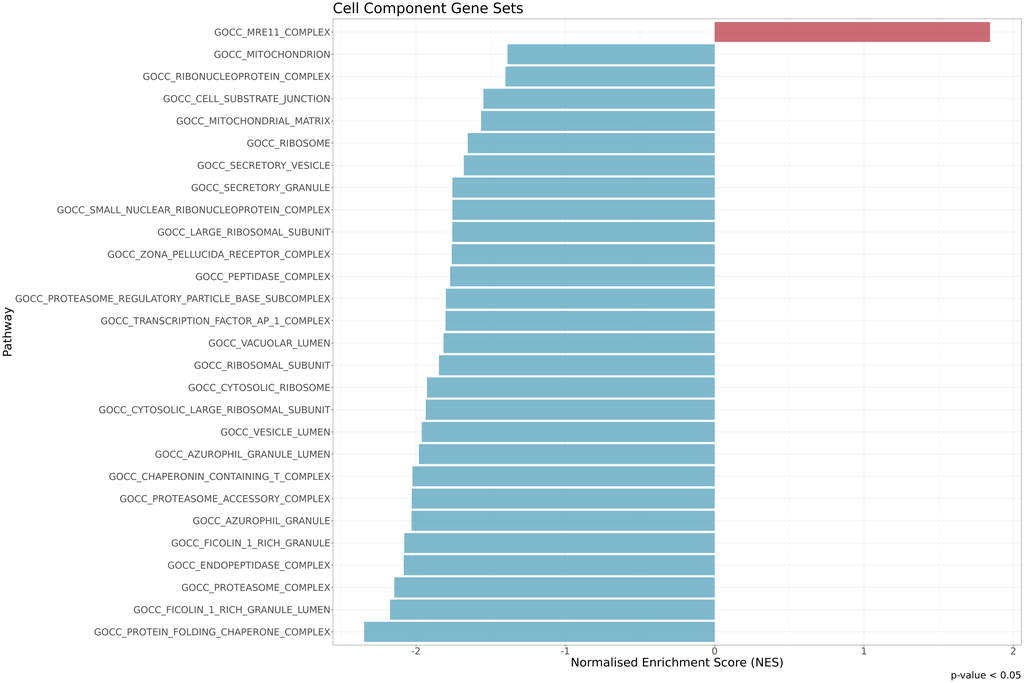

```r
hallmarks.res.tidy <- hallmarks.res %>%
  as_tibble() %>%
  arrange(desc(NES))

hallmarks.res.tidy %>%
  dplyr::select(-leadingEdge, -ES) %>%
  arrange(padj)

hallmark.sg.t <- hallmarks.res.tidy[,c(1,3,6)]
hallmark.sg.t <- as.data.frame(hallmark.sg.t)

#this small part is generic
thresh <- 0.05

#this one is no longer generic
data_to_plot <- hallmarks.res.tidy %>% filter(padj < thresh)

statvec <- c()
for (i in 1:nrow(data_to_plot)){
  if (data_to_plot[i,6] > 0){
    status <- "Upregulated"
  }
 else {
   status <- "Downregulated"
 }
statvec <- c(statvec, status)
}

data_to_plot$Status <- statvec

##GOCC
gsea_plot_hall <- ggplot(data_to_plot, aes(reorder(pathway, NES), NES)) +
  geom_col(aes(fill= Status), alpha=0.75) + scale_fill_manual(values = c("#53A2BE","#BA3B46"), name = "Regulation Status", labels = c("Downregulated", "Upregulated"), breaks = c("Downregulated", "Upregulated")) +
  coord_flip() +
  labs(x="Pathway", y="Normalised Enrichment Score (NES)",
       title= "Cell Component Gene Sets",
       caption = paste0("p-value < ", thresh)) + theme(plot.title = element_text(hjust = 1)) +
  theme_bw() + theme(text=element_text(family = "Quicksand")) + theme(legend.position = "none")


gsea_plot_hall+
  theme(text=element_text(size=25,  family="Arial MS"))
```

```r
### HALLMARK

#to load our pathways
hallmarks.gs <- msigdbr(species = "Homo sapiens", collection =  "H")

hallmarks.gsets <- hallmarks.gs %>% split(x = .$gene_symbol, f = .$gs_name)

for (set in names(hallmarks.gsets)){
  hallmarks.gsets[[set]] <- toupper(hallmarks.gsets[[set]])
}

hallmarks.res <- fgsea(pathways = hallmarks.gsets,
                       stats = vectorranks)
```

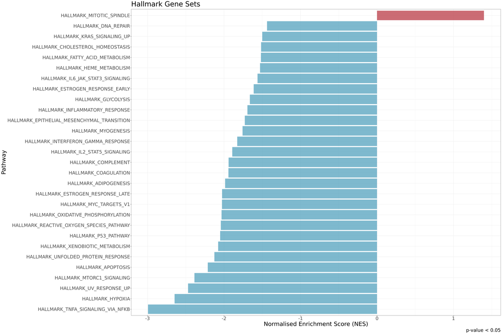

```r
hallmarks.res.tidy <- hallmarks.res %>%
  as_tibble() %>%
  arrange(desc(NES))

hallmarks.res.tidy %>%
  dplyr::select(-leadingEdge, -ES) %>%
  arrange(padj)

hallmark.sg.t <- hallmarks.res.tidy[,c(1,3,6)]
hallmark.sg.t <- as.data.frame(hallmark.sg.t)

#this small part is generic
thresh <- 0.05

#this one is no longer generic
data_to_plot <- hallmarks.res.tidy %>% filter(padj < thresh)

statvec <- c()
for (i in 1:nrow(data_to_plot)){
  if (data_to_plot[i,6] > 0){
    status <- "Upregulated"
  }
 else {
   status <- "Downregulated"
 }
statvec <- c(statvec, status)
}

data_to_plot$Status <- statvec

##-----HALMARK-----
gsea_plot_hall <- ggplot(data_to_plot, aes(reorder(pathway, NES), NES)) +
  geom_col(aes(fill= Status), alpha=0.75) + scale_fill_manual(values = c("#53A2BE","#BA3B46"), name = "Regulation Status", labels = c("Downregulated", "Upregulated"), breaks = c("Downregulated", "Upregulated")) +
  coord_flip() +
  labs(x="Pathway", y="Normalised Enrichment Score (NES)",
       title= "Hallmark Gene Sets",
       caption = paste0("p-value < ", thresh)) + theme(plot.title = element_text(hjust = 1)) +
  theme_bw() + theme(text=element_text(family = "Quicksand")) + theme(legend.position = "none")


gsea_plot_hall+
  theme(text=element_text(size=25,  family="Arial MS"))
```

[^1]: Disease Transcriptomics Group, Gulbenkian Institute of Molecular Medicine